# Analyzing the Reptile data for State of Nature Report 2023

Orr Comay

2024-02-08

## Setup

First, load the required R packages:

```r
# Setup----
library(tidyverse)
library(readxl)
library(data.table)
library(glmmTMB) # For generalized linear mixed models
library(gllvm)
library(jtools)
library(sf) # For vector GIS objects
library(raster)
```

```r
library(interactions) # For interaction plots
library(glmmTMB) # For generalized linear mixed models
library(broom.mixed) # easily extract model coefficients
library(extrafont)
library(Cairo) # Export as vector pdf
library(emmeans) # For pairwise comparison among factor levels
library(DHARMa) # Examining GLMM model fit
library(terra) # for handling raster data
library(renv)
Sys.setlocale("LC_ALL", "Hebrew") # For reading and writing csv files with Hebrew
```

```
## [1] "LC_COLLATE=Hebrew_Israel.1255;LC_CTYPE=Hebrew_Israel.1255;LC_MONETARY=Hebrew_Israel.1255;LC_NUMERIC=C;LC_TIME=Hebrew_Israel.1255"
```

```r
# knitr::opts_knit$set(root.dir = 'C:/Users/User/OneDrive - Tel-Aviv University/Maarag/State of Nature Report/2023/git/Reptiles') # Change this to your file path
okabe <- c("#E69F00", "#56B4E9", "#009E73", "#F0E442", "#0072B2", "#D55E00", "#CC79A7", 'red')
```

If need be, register the fonts (only once per computer):

```r
# loadfonts()
```

Define the standards (font, output size and reverse Hebrew text) for graphical output:

```r
fontname = "Almoni ML v5 AAA"
fontsize=22
pdf_width=160
pdf_aspect_ratio = 2/3
strReverse <- function(x){sapply(lapply(strsplit(x, NULL), rev), paste, collapse="")} # To reverse the order of (Hebrew) text for export as vector pdf
```

Load the raw reptile data:

```r
# Load the data----
reptiles <- readRDS("../data/wrangled_reptile_data_T0-T4.rds")
#reptiles <- fread("../data/wrangled reptile data T0-T4.csv")
```

## Alpha diveristy

Generate a table of alpha diversity: species richness, total reptile abundance and geometric mean abundance per survey (defined here as a unique plot-campaign combination).

```r
# Define the left hand side (LHS) of the casting function (i.e. the variables defining the survey event itself rather than species found in the survey = the identity variables):
LHS <- c('unit', 'year','campaign', 'subunit', 'site', 'point_name','survey_ID', 'Date', 'sin.dist.21.June','cos.dist.21.June',
         'sin.dist.noon','cos.dist.noon','settlements','agriculture','dunes','habitat','mean.lon','mean.lat')
# Species richness
sp.richness.data <- reptiles[count_individuals > 0, .(species.richness = uniqueN(SciName)), keyby = LHS]
sp.richness.data[, uniqueN(survey_ID)] # 630 surveys over all
```

```
## [1] 630
```

```r
sp.richness.data[, .N, keyby = survey_ID][N > 1] # 2 cases of more than one row per survey
```

```
## Key: <survey_ID>
## Empty data.table (0 rows and 2 cols): survey_ID,N
```

```r
sp.richness.data[survey_ID %in% sp.richness.data[, .N, keyby = survey_ID][N > 1, survey_ID]]
```

```
## Key: <unit, year, campaign, subunit, site, point_name, survey_ID, Date, sin.dist.21.June, cos.dist.21.June, sin.dist.noon, cos.dist.noon, settlements, agriculture, dunes, habitat, mean.lon, mean.lat>
## Empty data.table (0 rows and 19 cols): unit,year,campaign,subunit,site,point_name...
```

```r
reptiles[survey_ID %in% sp.richness.data[, .N, keyby = survey_ID][N > 1, survey_ID], .SD, .SDcols = LHS] # Mean coordinates are NA in two rows in Kerem Maharal Kkl Plantings 1
```

```
## Empty data.table (0 rows and 18 cols): unit,year,campaign,subunit,site,point_name...
```

```r
sp.richness.data[, min(species.richness)] # no zero species richness plots here though
```

```
## [1] 1
```

```r
sp.richness.data <- rbind(sp.richness.data, reptiles[count_individuals == 0, .(species.richness = 0), keyby = LHS]) # add all the zero species richness surveys
sp.richness.data[, uniqueN(survey_ID)] # Now there are 697 surveys
```

```
## [1] 691
```

```r
# Total plot abundance, with rare species
total.abnd <- reptiles[, .(total.abundance = sum(count_individuals)), keyby = LHS]
total.abnd[, uniqueN(survey_ID)] # 697 surveys over all, same as with the species richness
```

```
## [1] 691
```

```r
# Total plot abundance, without rare species
total.abnd.no.rare <- reptiles[is.rare.in.unit == F | count_individuals == 0, .(total.abundance = sum(count_individuals)), keyby = LHS]
total.abnd.no.rare[, uniqueN(survey_ID)] # 645 surveys including only non-rare species
```

```
## [1] 678
```

```r
reptiles[is.rare.in.unit == F, .(total.abundance = sum(count_individuals)), keyby = LHS]
```

```
## Key: <unit, year, campaign, subunit, site, point_name, survey_ID, Date, sin.dist.21.June, cos.dist.21.June, sin.dist.noon, cos.dist.noon, settlements, agriculture, dunes, habitat, mean.lon, mean.lat>
##                         unit  year campaign          subunit            site
##                       <fctr> <num>   <fctr>           <fctr>          <fctr>
##   1:     Coastal Plain Sands  2014       T0             <NA>          Ashdod
##   2:     Coastal Plain Sands  2014       T0             <NA>          Ashdod
##   3:     Coastal Plain Sands  2014       T0             <NA>          Ashdod
##   4:     Coastal Plain Sands  2014       T0             <NA>          Ashdod
##   5:     Coastal Plain Sands  2014       T0             <NA>          Ashdod
##  ---
## 678: Planted Conifer Forests  2021       T4 Judean Highlands         Eshtaol
## 679: Planted Conifer Forests  2021       T4 Judean Highlands         Eshtaol
## 680: Planted Conifer Forests  2021       T4 Judean Highlands         Eshtaol
## 681: Planted Conifer Forests  2021       T4 Judean Highlands Givat Yeshayahu
## 682: Planted Conifer Forests  2021       T4 Judean Highlands Givat Yeshayahu
##                            point_name                           survey_ID
```

[output cut: 51 more lines]

```r
# geometric mean abundance, without rare species - THIS IS IRRELEVANT AS WE DECIDED NOT TO CALCULATE GMA
rept.total.abnd.per.sp <- reptiles[is.rare.in.unit == F, .(Total.sp.abnd = sum(count_individuals, na.rm = T)),
                                                  keyby = c(LHS, 'SciName')]
rept.total.abnd.per.sp[!is.na(Total.sp.abnd) & Total.sp.abnd > 0, uniqueN(survey_ID)] # 578 surveys including non-rare species
```

```
## [1] 617
```

```r
gma.no.rare <- rept.total.abnd.per.sp[, .(geom.mean.abundance = exp(mean(log(Total.sp.abnd)))), keyby = c(LHS)]
gma.no.rare[, uniqueN(survey_ID)] # 640 surveys including non-rare species
```

```
## [1] 678
```

```r
reptiles[, .(total.count = sum(count_individuals)), keyby = .(unit, is.rare.in.unit)] # Note that rare species consist a considerable portion of the data
```

```
## Key: <unit, is.rare.in.unit>
##                                          unit is.rare.in.unit total.count
##                                        <fctr>          <lgcl>       <num>
##  1:                       Coastal Plain Sands           FALSE        1053
##  2:                       Coastal Plain Sands            TRUE          29
##  3:                              Inland Sands           FALSE         567
##  4:                              Inland Sands            TRUE          27
##  5: Loess Covered Areas in the Northern Negev           FALSE         250
##  6: Loess Covered Areas in the Northern Negev            TRUE          33
##  7:      Mediterranean-Desert Transition Zone           FALSE         356
##  8:      Mediterranean-Desert Transition Zone            TRUE          53
##  9:                   Planted Conifer Forests           FALSE         426
## 10:                   Planted Conifer Forests            TRUE          55
```

```r
# Define a table of all three alpha diversity indices:
alpha.div <- merge(sp.richness.data, total.abnd, by = LHS, all = T) # merge species richness and total plot abundance (including rare species)
alpha.div <- merge(alpha.div, gma.no.rare, by = LHS, all = T) # add also geometric mean abundance (omitting rare species)
# alpha.div <- merge(alpha.div, reptiles[, .(year = unique(year)), keyby = .(unit, campaign)], by = c('unit', 'campaign'), all.x = T) # add the first year of the campaign
alpha.div[, ':=' (year.count = year - min(year), year.fct = as.factor(year)), keyby = unit]
alpha.div[, .(first.year = min(year), first.year.count = min(year.count)), keyby = unit]
```

```
## Key: <unit>
##                                         unit first.year first.year.count
##                                       <fctr>      <num>            <num>
## 1:                       Coastal Plain Sands       2014                0
## 2:                              Inland Sands       2017                0
## 3: Loess Covered Areas in the Northern Negev       2014                0
## 4:      Mediterranean-Desert Transition Zone       2014                0
## 5:                   Planted Conifer Forests       2014                0
```

```r
alpha.div[is.na(species.richness), .N] # no cases of missing species richness
```

```
## [1] 0
```

```r
alpha.div[is.na(total.abundance), .N] # no  cases of missing total abundance
```

```
## [1] 0
```

```r
alpha.div[is.na(geom.mean.abundance), .N] # 53 cases of missing geometric mean abundance, though!
```

```
## [1] 13
```

```r
alpha.div[is.na(geom.mean.abundance) & !survey_ID %in% reptiles[is.rare.in.unit == T, survey_ID], ] # all of them in surveys where only rare species were found
```

```
## Key: <unit>
## Empty data.table (0 rows and 23 cols): unit,year,campaign,subunit,site,point_name...
```

```r
reptiles[survey_ID %in% alpha.div[is.na(geom.mean.abundance), survey_ID] & is.rare.in.unit == F,
         .(survey_ID, SciName, count_individuals, is.rare.in.unit)]
```

```
## Empty data.table (0 rows and 4 cols): survey_ID,SciName,count_individuals,is.rare.in.unit
```

```r
rept.total.abnd.per.sp[survey_ID %in% alpha.div[is.na(geom.mean.abundance), survey_ID],
         .(survey_ID, SciName, Total.sp.abnd)] #
```

```
## Empty data.table (0 rows and 3 cols): survey_ID,SciName,Total.sp.abnd
```

```r
gma.no.rare[is.na(geom.mean.abundance), unique(survey_ID)]
```

```
## factor()
## 691 Levels: T0_Aderet 31.67867469_34.98154177 ... T4_Zuriel Kkl Plantings 3
```

```r
alpha.div[, .(no.of.surveys = uniqueN(survey_ID))] # 697 surveys
```

```
##    no.of.surveys
##            <int>
## 1:           691
```

```r
alpha.div[, .(no.of.surveys = uniqueN(survey_ID)), keyby = unit] # 5 units
```

```
## Key: <unit>
##                                         unit no.of.surveys
##                                       <fctr>         <int>
## 1:                       Coastal Plain Sands           170
## 2:                              Inland Sands            72
## 3: Loess Covered Areas in the Northern Negev           112
## 4:      Mediterranean-Desert Transition Zone           119
## 5:                   Planted Conifer Forests           218
```

```r
str(alpha.div)
```

```
## Classes 'data.table' and 'data.frame':   695 obs. of  23 variables:
##  $ unit               : Factor w/ 5 levels "Coastal Plain Sands",..: 1 1 1 1 1 1 1 1 1 1 ...
##  $ year               : num  2014 2014 2014 2014 2014 ...
##  $ campaign           : Factor w/ 5 levels "T0","T1","T2",..: 1 1 1 1 1 1 1 1 1 1 ...
##  $ subunit            : Factor w/ 3 levels "Carmel","Galilee",..: NA NA NA NA NA NA NA NA NA NA ...
##  $ site               : Factor w/ 35 levels "Aderet","Amatzia",..: 3 3 3 3 3 3 3 3 3 4 ...
##  $ point_name         : Factor w/ 281 levels "Aderet 31.67144877_34.9880248",..: 12 13 14 15 16 17 18 19 20 21 ...
##  $ survey_ID          : Factor w/ 691 levels "T0_Aderet 31.67867469_34.98154177",..: 7 8 9 10 11 12 13 14 15 16 ...
##  $ Date               : Date, format: "2014-09-30" "2014-09-30" ...
##  $ sin.dist.21.June   : num  0.986 0.986 0.986 0.986 0.986 ...
##  $ cos.dist.21.June   : num  -0.167 -0.167 -0.167 -0.167 -0.167 ...
##  $ sin.dist.noon      : num  0.758 0.383 0.679 0.609 0.548 ...
##  $ cos.dist.noon      : num  0.653 0.924 0.734 0.793 0.836 ...
##  $ settlements        : Factor w/ 2 levels "Far","Near": 1 1 1 1 1 1 2 2 2 1 ...
##  $ agriculture        : Factor w/ 2 levels "Far","Near": NA NA NA NA NA NA NA NA NA NA ...
##  $ dunes              : Factor w/ 2 levels "semi-shifting",..: 1 1 1 2 2 2 1 1 1 1 ...
##  $ habitat            : Factor w/ 3 levels "bedouin agriculture",..: NA NA NA NA NA NA NA NA NA NA ...
##  $ mean.lon           : num  34.6 34.6 34.6 34.6 34.6 ...
##  $ mean.lat           : num  31.8 31.8 31.8 31.8 31.8 ...
##  $ species.richness   : num  3 4 3 3 3 4 4 3 4 6 ...
##  $ total.abundance    : num  6 7 17 5 6 6 5 4 5 9 ...
##  $ geom.mean.abundance: num  1.59 1.57 2.47 1.59 1.59 ...
##  $ year.count         : num  0 0 0 0 0 0 0 0 0 0 ...
##  $ year.fct           : Factor w/ 8 levels "2014","2015",..: 1 1 1 1 1 1 1 1 1 1 ...
##  - attr(*, "sorted")= chr "unit"
##  - attr(*, ".internal.selfref")=<externalptr>
```

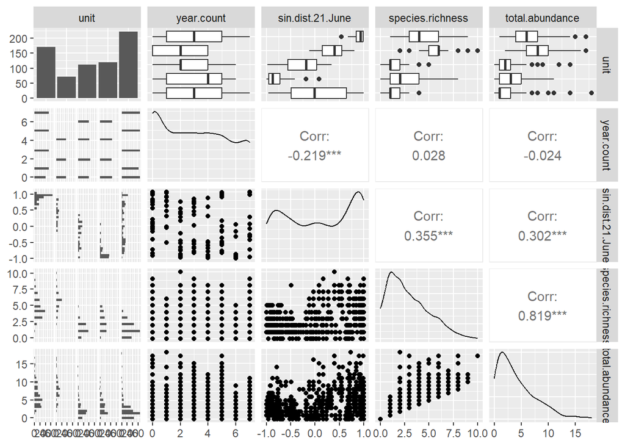

```r
GGally::ggpairs(alpha.div[, .(unit, year.count, sin.dist.21.June, species.richness, total.abundance)], progress = F) # species richness and total abundance are highly correlated (0.82)
```

## Coastal Plain Dunes

The models are rank-deficient: in the Near plots there are only semi-shifting dunes (this is the study design). Also note the site identities:

```r
coast <- alpha.div[unit == 'Coastal Plain Sands'] # subset the coast plain sands
str(coast)
```

```
## Classes 'data.table' and 'data.frame':   170 obs. of  23 variables:
##  $ unit               : Factor w/ 5 levels "Coastal Plain Sands",..: 1 1 1 1 1 1 1 1 1 1 ...
##  $ year               : num  2014 2014 2014 2014 2014 ...
##  $ campaign           : Factor w/ 5 levels "T0","T1","T2",..: 1 1 1 1 1 1 1 1 1 1 ...
##  $ subunit            : Factor w/ 3 levels "Carmel","Galilee",..: NA NA NA NA NA NA NA NA NA NA ...
##  $ site               : Factor w/ 35 levels "Aderet","Amatzia",..: 3 3 3 3 3 3 3 3 3 4 ...
##  $ point_name         : Factor w/ 281 levels "Aderet 31.67144877_34.9880248",..: 12 13 14 15 16 17 18 19 20 21 ...
##  $ survey_ID          : Factor w/ 691 levels "T0_Aderet 31.67867469_34.98154177",..: 7 8 9 10 11 12 13 14 15 16 ...
##  $ Date               : Date, format: "2014-09-30" "2014-09-30" ...
##  $ sin.dist.21.June   : num  0.986 0.986 0.986 0.986 0.986 ...
##  $ cos.dist.21.June   : num  -0.167 -0.167 -0.167 -0.167 -0.167 ...
##  $ sin.dist.noon      : num  0.758 0.383 0.679 0.609 0.548 ...
##  $ cos.dist.noon      : num  0.653 0.924 0.734 0.793 0.836 ...
##  $ settlements        : Factor w/ 2 levels "Far","Near": 1 1 1 1 1 1 2 2 2 1 ...
##  $ agriculture        : Factor w/ 2 levels "Far","Near": NA NA NA NA NA NA NA NA NA NA ...
##  $ dunes              : Factor w/ 2 levels "semi-shifting",..: 1 1 1 2 2 2 1 1 1 1 ...
##  $ habitat            : Factor w/ 3 levels "bedouin agriculture",..: NA NA NA NA NA NA NA NA NA NA ...
##  $ mean.lon           : num  34.6 34.6 34.6 34.6 34.6 ...
##  $ mean.lat           : num  31.8 31.8 31.8 31.8 31.8 ...
##  $ species.richness   : num  3 4 3 3 3 4 4 3 4 6 ...
##  $ total.abundance    : num  6 7 17 5 6 6 5 4 5 9 ...
##  $ geom.mean.abundance: num  1.59 1.57 2.47 1.59 1.59 ...
##  $ year.count         : num  0 0 0 0 0 0 0 0 0 0 ...
##  $ year.fct           : Factor w/ 8 levels "2014","2015",..: 1 1 1 1 1 1 1 1 1 1 ...
##  - attr(*, "sorted")= chr "unit"
##  - attr(*, ".internal.selfref")=<externalptr>
```

```r
coast[is.na(settlements) | is.na(dunes)] # no missing variables
```

```
## Key: <unit>
## Empty data.table (0 rows and 23 cols): unit,year,campaign,subunit,site,point_name...
```

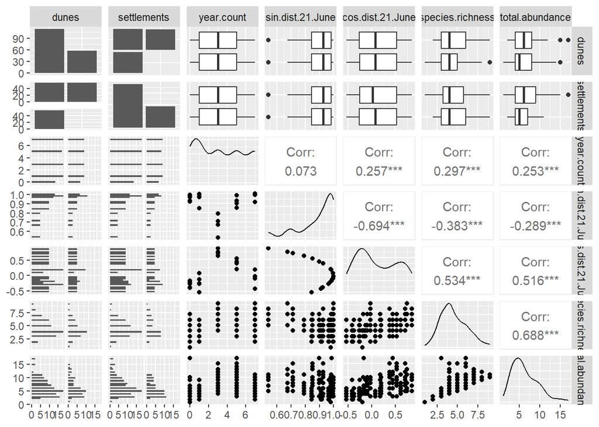

```r
GGally::ggpairs(coast[, .(dunes, settlements, year.count, sin.dist.21.June, cos.dist.21.June, # we do not include the time of day in the sands protocol as it includes both morning and afternoon survey in the same plot
                           species.richness, total.abundance)], progress = F)
```

```r
coast[, sort(unique(site))]
```

```
## [1] Ashdod        Ashkelon      Caesarea      Netiv Haasara Zikim
## 35 Levels: Aderet Amatzia Ashdod Ashkelon Bat Shlomo Beer Milka ... Zuriel
```

Following the practice for arthropods recommended by Ittai Renan and a similar recommendation by Ron Chen, we will replace the site identity with a comparison between the northern Coastal Plain dunes (represented only by Caesarea) and the southern ones (all other sites):

```r
coast[, Region := ifelse(site == 'Caesarea', 'North', 'South')]
coast[, .(site = sort(unique(site))), keyby = Region]
```

```
## Key: <Region>
##    Region          site
##    <char>        <fctr>
## 1:  North      Caesarea
## 2:  South        Ashdod
## 3:  South      Ashkelon
## 4:  South Netiv Haasara
## 5:  South         Zikim
```

Now, as the Region predictor has only two levels (North or South), we cannot treat it as a random predictor. Instead, it will be treated as a fixed predictor that will not be allowed to drop due to AIC.

Species richness model selection:

```r
# Coastal Dunes species richness - glmm model selection ----
coast[, .(mean.species.richness = mean(species.richness), var.sp.rich = var(species.richness)), keyby = .(year)] # 2014-2015 are lower
```

```
## Key: <year>
##     year mean.species.richness var.sp.rich
##    <num>                 <num>       <num>
## 1:  2014              3.629630   1.6267806
## 2:  2015              3.416667   0.9357143
## 3:  2017              5.777778   2.1777778
## 4:  2019              5.114286   1.4571429
## 5:  2021              4.611111   2.9301587
```

```r
coast[, .(mean.species.richness = mean(species.richness), var.sp.rich = var(species.richness)), keyby = .(settlements)] # same
```

```
## Key: <settlements>
##    settlements mean.species.richness var.sp.rich
##         <fctr>                 <num>       <num>
## 1:         Far              4.517544    2.340397
## 2:        Near              4.625000    3.147727
```

```r
coast[, .(mean.species.richness = mean(species.richness), var.sp.rich = var(species.richness)), keyby = .(dunes)] # same
```

```
## Key: <dunes>
##            dunes mean.species.richness var.sp.rich
##           <fctr>                 <num>       <num>
## 1: semi-shifting              4.646018    2.605721
## 2:      shifting              4.368421    2.558271
```

```r
coast[, .(mean.species.richness = mean(species.richness), var.sp.rich = var(species.richness)), keyby = .(site)] # Netiv Haasara is lower than the rest at 3.3 species vs. 4-5
```

```
## Key: <site>
##             site mean.species.richness var.sp.rich
##           <fctr>                 <num>       <num>
## 1:        Ashdod              4.511111    1.801010
## 2:      Ashkelon              5.022222    3.931313
## 3:      Caesarea              4.171429    1.440336
## 4: Netiv Haasara              3.333333    1.250000
## 5:         Zikim              4.694444    2.789683
```

```r
coast[, .(mean.richness = mean(species.richness), var.richness = var(species.richness))] # var < mean -> try Poisson models
```

```
##    mean.richness var.richness
##            <num>        <num>
## 1:      4.552941     2.591855
```

```r
# Full model, Poisson response
coast.sp.rich.model.full.Poisson <- glmmTMB(species.richness ~ settlements * dunes + sin.dist.21.June + cos.dist.21.June + Region,  family = 'poisson', data = coast)
```

```
## dropping columns from rank-deficient conditional model: settlementsNear:dunesshifting
```

```r
summary(coast.sp.rich.model.full.Poisson)
```

```
##  Family: poisson  ( log )
## Formula:
## species.richness ~ settlements * dunes + sin.dist.21.June + cos.dist.21.June +
##     Region
## Data: coast
##
##      AIC      BIC   logLik deviance df.resid
##    644.5    663.3   -316.2    632.5      164
##
##
## Conditional model:
##                               Estimate Std. Error z value Pr(>|z|)
## (Intercept)                    1.26524    0.38829   3.259 0.001120 **
## settlementsNear               -0.01372    0.08730  -0.157 0.875129
## dunesshifting                 -0.07002    0.08819  -0.794 0.427186
## sin.dist.21.June               0.14771    0.39866   0.371 0.711009
## cos.dist.21.June               0.47091    0.12717   3.703 0.000213 ***
## RegionSouth                    0.09175    0.09279   0.989 0.322763
## settlementsNear:dunesshifting       NA         NA      NA       NA
## ---
## Signif. codes:  0 '***' 0.001 '**' 0.01 '*' 0.05 '.' 0.1 ' ' 1
```

```r
cat('PHI = '); deviance(coast.sp.rich.model.full.Poisson)/df.residual(coast.sp.rich.model.full.Poisson)
```

```
## PHI =
```

```
## [1] 0.4037897
```

```r
drop1(coast.sp.rich.model.full.Poisson) # can drop sin seasonality
```

```
## dropping columns from rank-deficient conditional model: settlementsNear:dunesshifting
## dropping columns from rank-deficient conditional model: settlementsNear:dunesshifting
## dropping columns from rank-deficient conditional model: settlementsNear:dunesshifting
```

```
## Single term deletions
##
## Model:
## species.richness ~ settlements * dunes + sin.dist.21.June + cos.dist.21.June +
##     Region
##                   Df    AIC
## <none>               644.48
## sin.dist.21.June   1 642.62
## cos.dist.21.June   1 656.86
## Region             1 643.47
## settlements:dunes  0 644.48
```

```r
coast.sp.rich.model1 <- glmmTMB(species.richness ~ settlements + dunes + sin.dist.21.June + cos.dist.21.June + Region,  family = 'poisson', data = coast)
summary(coast.sp.rich.model1)
```

```
##  Family: poisson  ( log )
## Formula:
## species.richness ~ settlements + dunes + sin.dist.21.June + cos.dist.21.June +
##     Region
## Data: coast
##
##      AIC      BIC   logLik deviance df.resid
##    644.5    663.3   -316.2    632.5      164
##
##
## Conditional model:
##                  Estimate Std. Error z value Pr(>|z|)
## (Intercept)       1.26524    0.38829   3.259 0.001120 **
## settlementsNear  -0.01372    0.08730  -0.157 0.875129
## dunesshifting    -0.07002    0.08819  -0.794 0.427186
## sin.dist.21.June  0.14771    0.39866   0.371 0.711009
## cos.dist.21.June  0.47091    0.12717   3.703 0.000213 ***
## RegionSouth       0.09175    0.09279   0.989 0.322763
## ---
## Signif. codes:  0 '***' 0.001 '**' 0.01 '*' 0.05 '.' 0.1 ' ' 1
```

```r
drop1(coast.sp.rich.model1)
```

```
## Single term deletions
##
## Model:
## species.richness ~ settlements + dunes + sin.dist.21.June + cos.dist.21.June +
##     Region
##                  Df    AIC
## <none>              644.48
## settlements       1 642.50
## dunes             1 643.11
## sin.dist.21.June  1 642.62
## cos.dist.21.June  1 656.86
## Region            1 643.47
```

Now we have an AIC score (644.5) and no warnings. The function drop1 suggests we can further drop the distance to settlements. Proceed to dropping predictors one by one due to AIC selection:

```r
coast.sp.rich.model2 <- glmmTMB(species.richness ~ dunes + sin.dist.21.June + cos.dist.21.June + Region,  family = 'poisson', data = coast)
summary(coast.sp.rich.model2)
```

```
##  Family: poisson  ( log )
## Formula:
## species.richness ~ dunes + sin.dist.21.June + cos.dist.21.June +      Region
## Data: coast
##
##      AIC      BIC   logLik deviance df.resid
##    642.5    658.2   -316.3    632.5      165
##
##
## Conditional model:
##                  Estimate Std. Error z value Pr(>|z|)
## (Intercept)       1.25893    0.38622   3.260 0.001116 **
## dunesshifting    -0.06323    0.07696  -0.822 0.411267
## sin.dist.21.June  0.14734    0.39865   0.370 0.711681
## cos.dist.21.June  0.47073    0.12716   3.702 0.000214 ***
## RegionSouth       0.09159    0.09278   0.987 0.323571
## ---
## Signif. codes:  0 '***' 0.001 '**' 0.01 '*' 0.05 '.' 0.1 ' ' 1
```

```r
drop1(coast.sp.rich.model2)
```

```
## Single term deletions
##
## Model:
## species.richness ~ dunes + sin.dist.21.June + cos.dist.21.June +
##     Region
##                  Df    AIC
## <none>              642.50
## dunes             1 641.18
## sin.dist.21.June  1 640.64
## cos.dist.21.June  1 654.87
## Region            1 641.50
```

AIC has decreased and can be further decreased if we drop sine seasonality as well:

```r
coast.sp.rich.model3 <- glmmTMB(species.richness ~ dunes + cos.dist.21.June + Region,  family = 'poisson', data = coast)
summary(coast.sp.rich.model3)
```

```
##  Family: poisson  ( log )
## Formula:          species.richness ~ dunes + cos.dist.21.June + Region
## Data: coast
##
##      AIC      BIC   logLik deviance df.resid
##    640.6    653.2   -316.3    632.6      166
##
##
## Conditional model:
##                  Estimate Std. Error z value Pr(>|z|)
## (Intercept)       1.39789    0.08746  15.984  < 2e-16 ***
## dunesshifting    -0.06286    0.07695  -0.817    0.414
## cos.dist.21.June  0.43570    0.08433   5.166 2.39e-07 ***
## RegionSouth       0.08712    0.09201   0.947    0.344
## ---
## Signif. codes:  0 '***' 0.001 '**' 0.01 '*' 0.05 '.' 0.1 ' ' 1
```

```r
drop1(coast.sp.rich.model3)
```

```
## Single term deletions
##
## Model:
## species.richness ~ dunes + cos.dist.21.June + Region
##                  Df    AIC
## <none>              640.64
## dunes             1 639.31
## cos.dist.21.June  1 665.30
## Region            1 639.55
```

We can drop the dune type too:

```r
coast.sp.rich.model4 <- glmmTMB(species.richness ~ cos.dist.21.June + Region,  family = 'poisson', data = coast)
summary(coast.sp.rich.model4)
```

```
##  Family: poisson  ( log )
## Formula:          species.richness ~ cos.dist.21.June + Region
## Data: coast
##
##      AIC      BIC   logLik deviance df.resid
##    639.3    648.7   -316.7    633.3      167
##
##
## Conditional model:
##                  Estimate Std. Error z value Pr(>|z|)
## (Intercept)       1.37681    0.08372  16.445  < 2e-16 ***
## cos.dist.21.June  0.43542    0.08435   5.162 2.44e-07 ***
## RegionSouth       0.08772    0.09201   0.953     0.34
## ---
## Signif. codes:  0 '***' 0.001 '**' 0.01 '*' 0.05 '.' 0.1 ' ' 1
```

```r
drop1(coast.sp.rich.model4)
```

```
## Single term deletions
##
## Model:
## species.richness ~ cos.dist.21.June + Region
##                  Df    AIC
## <none>              639.31
## cos.dist.21.June  1 663.93
## Region            1 638.24
```

Although AIC can be lowered by removing the Region as well, we refrain from doing so as it is a substitute for the site (and plot) identities and is part of the study design. Hence, we have selected our final model, and now we should draw the model diagnostics:

```r
# The chosen model is coast.sp.rich.model4 (seasonal and diel patterns)
summary(coast.sp.rich.model4)
```

```
##  Family: poisson  ( log )
## Formula:          species.richness ~ cos.dist.21.June + Region
## Data: coast
##
##      AIC      BIC   logLik deviance df.resid
##    639.3    648.7   -316.7    633.3      167
##
##
## Conditional model:
##                  Estimate Std. Error z value Pr(>|z|)
## (Intercept)       1.37681    0.08372  16.445  < 2e-16 ***
## cos.dist.21.June  0.43542    0.08435   5.162 2.44e-07 ***
## RegionSouth       0.08772    0.09201   0.953     0.34
## ---
## Signif. codes:  0 '***' 0.001 '**' 0.01 '*' 0.05 '.' 0.1 ' ' 1
```

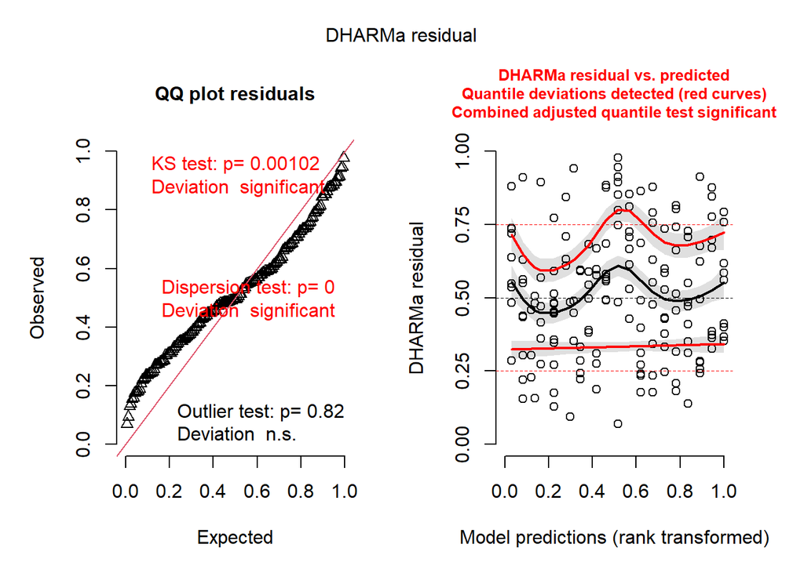

```r
coast.sp.rich.sim.res <- simulateResiduals(coast.sp.rich.model4) # simulate the residuals using DHARMa package for model diagnostics
plot(coast.sp.rich.sim.res)# The quantile, KS and dispersion tests are significant
```

The QQ plot does not look good: the Kolmogorov-Smirnov test is significant (meaning the data came from a different distribution than the model’s) and the dispersion test is significant as well. That might mean either over-dispersion (meaning increased type I error rate) or under-dispersion (meaning increased type II error, i.e. lower statistical power). We should investigate which one is it. In addition, the scaled residuals (scaled from 0 to 1, where 0 meaning all observed values are higher than the prediction and 1 meaning all observed values are lower than the predictions) test significant. Let’s further explore these issues:

```r
testQuantiles(coast.sp.rich.sim.res, plot = F) #
```

```
##
##  Test for location of quantiles via qgam
##
## data:  coast.sp.rich.sim.res
## p-value = 3.053e-06
## alternative hypothesis: both
```

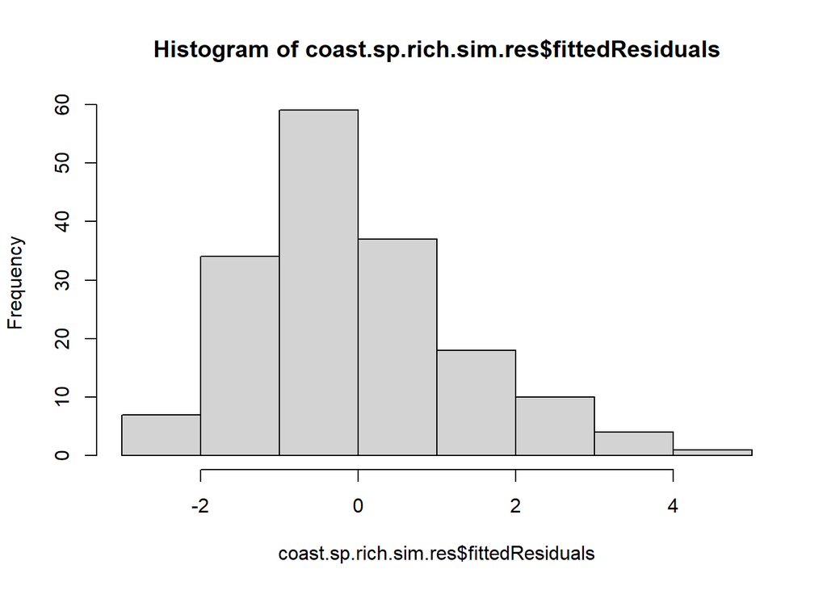

```r
hist(coast.sp.rich.sim.res$fittedResiduals) # right-tailed distribution
```

```r
quantile(coast.sp.rich.sim.res$fittedResiduals) # median residual = -0.21; inter-quartile range for residuals is -0.77 to +0.77
```

```
##         0%        25%        50%        75%       100%
## -2.9631933 -0.9655888 -0.1433060  0.7687454  4.7308806
```

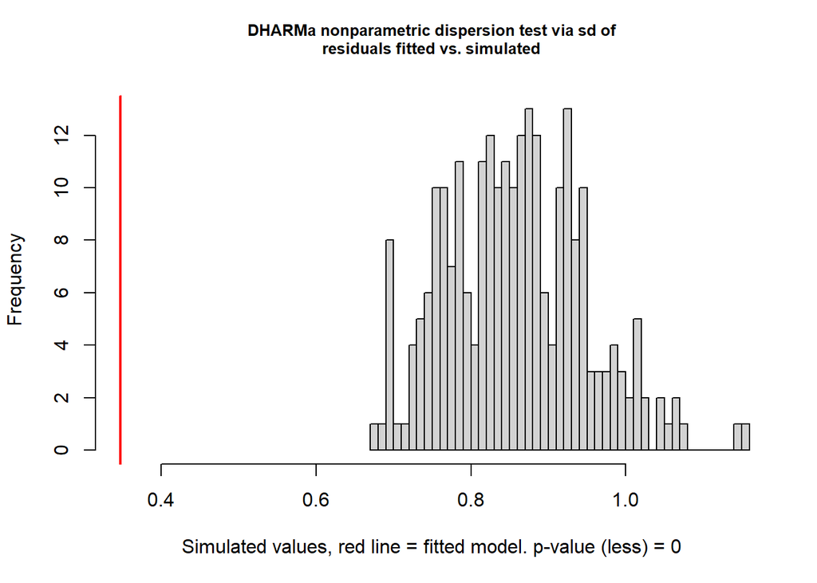

```
##
##  DHARMa nonparametric dispersion test via sd of residuals fitted vs.
##  simulated
##
## data:  simulationOutput
## dispersion = 0.4043, p-value < 2.2e-16
## alternative hypothesis: less
```

```r
testDispersion(coast.sp.rich.sim.res, alternative = 'less') # Significant (p < 2.2e-16) -> underdispersion
```

```r
testDispersion(coast.sp.rich.sim.res, alternative = 'greater', plot = F) # Insignificant (p = 1) -> not overdispersion
```

```
##
##  DHARMa nonparametric dispersion test via sd of residuals fitted vs.
##  simulated
##
## data:  simulationOutput
## dispersion = 0.4043, p-value = 1
## alternative hypothesis: greater
```

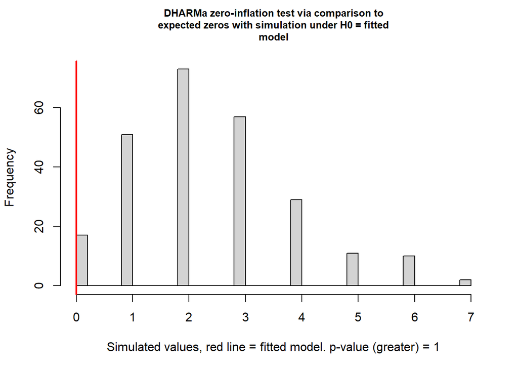

```
##
##  DHARMa zero-inflation test via comparison to expected zeros with
##  simulation under H0 = fitted model
##
## data:  simulationOutput
## ratioObsSim = 0, p-value = 1
## alternative hypothesis: greater
```

```r
testZeroInflation(coast.sp.rich.sim.res, alternative = 'greater') # p = 1, meaning there is no zero-inflation
```

```r
testZeroInflation(coast.sp.rich.sim.res, alternative = 'less', plot = F) # Significant (p = 0.04) -> fewer zeroes than expected
```

```
##
##  DHARMa zero-inflation test via comparison to expected zeros with
##  simulation under H0 = fitted model
##
## data:  simulationOutput
## ratioObsSim = 0, p-value = 0.068
## alternative hypothesis: less
```

```r
coast.sp.rich.model4b <- glmmTMB(species.richness ~ cos.dist.21.June + Region, family = 'poisson', data = coast, ziformula = ~ cos.dist.21.June + Region) # try correcting for zero-inflation
summary(coast.sp.rich.model4b) # AIC = 645.3 - getting worse!
```

```
##  Family: poisson  ( log )
## Formula:          species.richness ~ cos.dist.21.June + Region
## Zero inflation:                    ~cos.dist.21.June + Region
## Data: coast
##
##      AIC      BIC   logLik deviance df.resid
##    645.3    664.1   -316.7    633.3      164
##
##
## Conditional model:
##                  Estimate Std. Error z value Pr(>|z|)
## (Intercept)       1.37681    0.08372  16.445  < 2e-16 ***
## cos.dist.21.June  0.43542    0.08435   5.162 2.44e-07 ***
## RegionSouth       0.08772    0.09201   0.953     0.34
## ---
## Signif. codes:  0 '***' 0.001 '**' 0.01 '*' 0.05 '.' 0.1 ' ' 1
##
## Zero-inflation model:
##                    Estimate Std. Error z value Pr(>|z|)
## (Intercept)      -2.239e+01  1.234e+04  -0.002    0.999
## cos.dist.21.June -2.825e-03  1.227e+04   0.000    1.000
## RegionSouth       1.776e-01  1.357e+04   0.000    1.000
```

```r
# for (model in c(ls()[grep('*coast.sp.rich.model', ls())])){
#   capture.output(cat(model), cat('\n=========\n'), summary(get(model)), cat('\n=========\n'),
#                  file = '../output/Coastal Dunes - species richness model selection.txt', append = T)
# }

# save(list = ls()[grep('*coast.sp.rich.model', ls())], file = '../output/Coast Dunes - Species richness models.Rdata') # back up the models
# capture.output(cat('The best fitting model for species richness in the Coastal Dunes is coast.sp.rich.model4.'),
#                summary(coast.sp.rich.model4), cat('\n----\nNote that the model is underdispersed (i.e. has low power):\n'),
#                testDispersion(coast.sp.rich.sim.res, alternative = 'less', plot = F), # Significant (p < 2.2e-16) -> underdispersion
#                testDispersion(coast.sp.rich.sim.res, alternative = 'greater', plot = F), # Insignificant (p = 1) -> not overdispersion
#                testZeroInflation(coast.sp.rich.sim.res, alternative = 'greater', plot = F), # p = 1, meaning there is no zero-inflation
#                testZeroInflation(coast.sp.rich.sim.res, alternative = 'less', plot = F), # Significant (p < 2.2e-16) -> fewer zeroes than expected
#  file = '../output/Coastal Dunes species richness - best fitting model.txt', append = F)

# Create a table comparing total abundance models:
sp.rich.comparison <- data.table(unit = '', model = '',  data = '', family = '', formula = '', no.of.preds = 0, AIC = 0, BIC = 0) # Create a data.table to be filled by a loop
sp.rich.comparison <- sp.rich.comparison[AIC > 0] # empty the data.table

for(model in ls()[grep('*coast.sp.rich.model.', ls())]){
  sp.rich.comparison <- rbind(sp.rich.comparison,
                                 data.table(unit = 'Coast Sands', model = model,
                                            no.of.preds = length(attr(get(model)$modelInfo$terms$cond$fixed, 'term.labels')),
                                            AIC = AIC(get(model)), BIC = BIC(get(model)),
                                            data = as.character(get(model)$call$data),
                                            family = as.character(get(model)$call$family),
                                            formula = as.character(get(model)$call$formula)))
}
sp.rich.comparison <- sp.rich.comparison[!(formula %like% '~' | formula %like% 'species.richness')] # remove redundant rows
sp.rich.comparison <- unique(sp.rich.comparison)
setorder(sp.rich.comparison, unit, AIC)  # Sort by AIC (ascending)
sp.rich.comparison[unit == 'Coast Sands'] # View the table
```

```
##           unit                            model   data  family
##         <char>                           <char> <char>  <char>
## 1: Coast Sands             coast.sp.rich.model4  coast poisson
## 2: Coast Sands             coast.sp.rich.model3  coast poisson
## 3: Coast Sands             coast.sp.rich.model2  coast poisson
## 4: Coast Sands coast.sp.rich.model.full.Poisson  coast poisson
## 5: Coast Sands             coast.sp.rich.model1  coast poisson
## 6: Coast Sands            coast.sp.rich.model4b  coast poisson
##                                                               formula
##                                                                <char>
## 1:                                          cos.dist.21.June + Region
## 2:                                  dunes + cos.dist.21.June + Region
## 3:               dunes + sin.dist.21.June + cos.dist.21.June + Region
## 4: settlements * dunes + sin.dist.21.June + cos.dist.21.June + Region
## 5: settlements + dunes + sin.dist.21.June + cos.dist.21.June + Region
## 6:                                          cos.dist.21.June + Region
##    no.of.preds      AIC      BIC
##          <num>    <num>    <num>
## 1:           2 639.3128 648.7202
## 2:           3 640.6405 653.1837
## 3:           4 642.5035 658.1825
## 4:           6 644.4788 663.2936
## 5:           5 644.4788 663.2936
## 6:           2 645.3128 664.1276
```

Once we are done with the models not chosen, we can remove them from memory:

```r
rm(list = setdiff(ls()[grep('*coast.sp.rich.model', ls())], c('coast.sp.rich.model4'))) # Clean up
```

We do not bother predicting the species richness in the coastal plain since the chosen model contained no researcher hypotheses. Proceed to analyzing total reptile abundance:

Some data exploration:

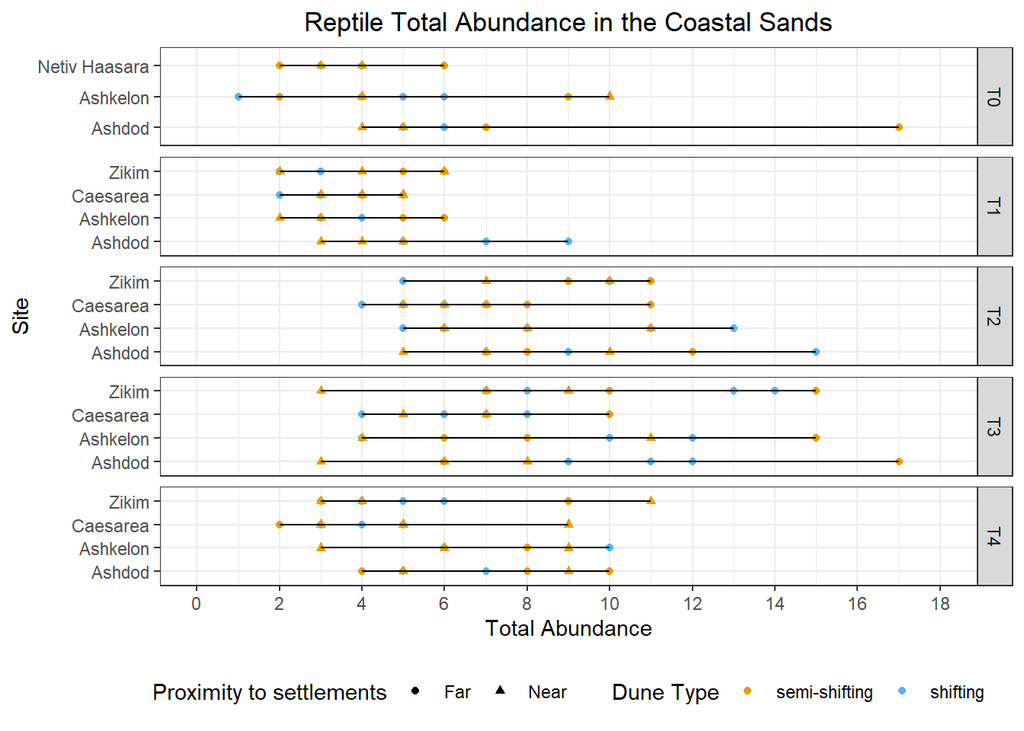

```r
# Coastal Dunes total abundance - glmm model selection ----
coast.abnd.dotplot <- ggplot(data = coast, aes(x = total.abundance, y = site)) +
  geom_point(aes(color = dunes, shape = settlements)) +  geom_line(aes(group = site)) +
  facet_grid(campaign ~ ., scales = 'free_y') + labs(title = 'Reptile Total Abundance in the Coastal Sands', y = 'Site', x = 'Total Abundance', color = 'Dune Type', shape = 'Proximity to settlements') +
  scale_color_manual(values = okabe) + scale_x_continuous(limits = c(0, coast[, max(total.abundance) + 1]),
                                                          breaks = seq(0, coast[, max(total.abundance) + 1], by = 2)) +
  theme_bw() + theme(legend.position = 'bottom',
                     plot.title = element_text(hjust = 0.5), plot.subtitle = element_text(hjust = 0.5))
coast.abnd.dotplot
```

```r
str(coast)
```

```
## Classes 'data.table' and 'data.frame':   170 obs. of  24 variables:
##  $ unit               : Factor w/ 5 levels "Coastal Plain Sands",..: 1 1 1 1 1 1 1 1 1 1 ...
##  $ year               : num  2014 2014 2014 2014 2014 ...
##  $ campaign           : Factor w/ 5 levels "T0","T1","T2",..: 1 1 1 1 1 1 1 1 1 1 ...
##  $ subunit            : Factor w/ 3 levels "Carmel","Galilee",..: NA NA NA NA NA NA NA NA NA NA ...
##  $ site               : Factor w/ 35 levels "Aderet","Amatzia",..: 3 3 3 3 3 3 3 3 3 4 ...
##  $ point_name         : Factor w/ 281 levels "Aderet 31.67144877_34.9880248",..: 12 13 14 15 16 17 18 19 20 21 ...
##  $ survey_ID          : Factor w/ 691 levels "T0_Aderet 31.67867469_34.98154177",..: 7 8 9 10 11 12 13 14 15 16 ...
##  $ Date               : Date, format: "2014-09-30" "2014-09-30" ...
##  $ sin.dist.21.June   : num  0.986 0.986 0.986 0.986 0.986 ...
##  $ cos.dist.21.June   : num  -0.167 -0.167 -0.167 -0.167 -0.167 ...
##  $ sin.dist.noon      : num  0.758 0.383 0.679 0.609 0.548 ...
##  $ cos.dist.noon      : num  0.653 0.924 0.734 0.793 0.836 ...
##  $ settlements        : Factor w/ 2 levels "Far","Near": 1 1 1 1 1 1 2 2 2 1 ...
##  $ agriculture        : Factor w/ 2 levels "Far","Near": NA NA NA NA NA NA NA NA NA NA ...
##  $ dunes              : Factor w/ 2 levels "semi-shifting",..: 1 1 1 2 2 2 1 1 1 1 ...
##  $ habitat            : Factor w/ 3 levels "bedouin agriculture",..: NA NA NA NA NA NA NA NA NA NA ...
##  $ mean.lon           : num  34.6 34.6 34.6 34.6 34.6 ...
##  $ mean.lat           : num  31.8 31.8 31.8 31.8 31.8 ...
##  $ species.richness   : num  3 4 3 3 3 4 4 3 4 6 ...
##  $ total.abundance    : num  6 7 17 5 6 6 5 4 5 9 ...
##  $ geom.mean.abundance: num  1.59 1.57 2.47 1.59 1.59 ...
##  $ year.count         : num  0 0 0 0 0 0 0 0 0 0 ...
##  $ year.fct           : Factor w/ 8 levels "2014","2015",..: 1 1 1 1 1 1 1 1 1 1 ...
##  $ Region             : chr  "South" "South" "South" "South" ...
##  - attr(*, "sorted")= chr "unit"
##  - attr(*, ".internal.selfref")=<externalptr>
```

```r
coast[, .(mean.abundance = mean(total.abundance, na.rm = T), var.abundance = var(total.abundance, na.rm = T))] # var >> mean -> try negative binomial
```

```
##    mean.abundance var.abundance
##             <num>         <num>
## 1:       6.364706       10.2449
```

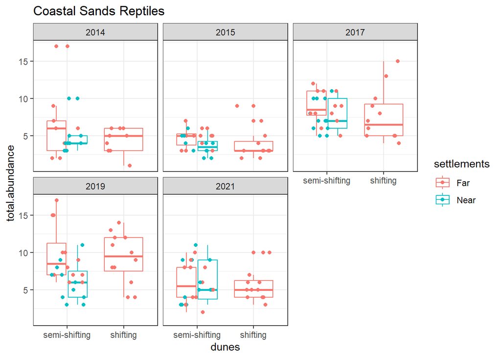

```r
ggplot(data = coast, aes(x = dunes, color = settlements, y = total.abundance)) + geom_boxplot() + labs(title = 'Coastal Sands Reptiles') + geom_jitter(height = 0, width = 0.3) +  facet_wrap(. ~ year) + theme_bw() # 2017-2019 seem higher than the other years
```

Ashdod semi-shifting Far in T0 and in T3 had counts of 17(!) reptiles, which seems like too much. Let’s have a look at that:

```r
reptiles[site == 'Ashdod' & campaign %in% c('T0', 'T3') & settlements == 'Far' & dunes == 'semi-shifting', .(total.individuals = sum(count_individuals)), keyby = .(survey_ID, campaign, Date)]
```

```
## Key: <survey_ID, campaign, Date>
##                        survey_ID campaign       Date total.individuals
##                           <fctr>   <fctr>     <Date>             <num>
## 1: T0_Ashdod Far Semi-Shifting 1       T0 2014-09-30                 6
## 2: T0_Ashdod Far Semi-Shifting 2       T0 2014-09-30                 7
## 3: T0_Ashdod Far Semi-Shifting 3       T0 2014-09-30                17
## 4: T3_Ashdod Far Semi-Shifting 1       T3 2019-08-25                 9
## 5: T3_Ashdod Far Semi-Shifting 2       T3 2019-08-25                 6
## 6: T3_Ashdod Far Semi-Shifting 3       T3 2019-08-25                17
```

```r
reptiles[point_name == 'Ashdod Far Semi-Shifting 3' & campaign %in% c('T0', 'T3'), .(total.ind = sum(count_individuals)), keyby = .(survey_ID, campaign, Date, SciName, heb_name)]
```

```
## Key: <survey_ID, campaign, Date, SciName, heb_name>
##                        survey_ID campaign       Date
##                           <fctr>   <fctr>     <Date>
## 1: T0_Ashdod Far Semi-Shifting 3       T0 2014-09-30
## 2: T0_Ashdod Far Semi-Shifting 3       T0 2014-09-30
## 3: T0_Ashdod Far Semi-Shifting 3       T0 2014-09-30
## 4: T3_Ashdod Far Semi-Shifting 3       T3 2019-08-25
## 5: T3_Ashdod Far Semi-Shifting 3       T3 2019-08-25
## 6: T3_Ashdod Far Semi-Shifting 3       T3 2019-08-25
## 7: T3_Ashdod Far Semi-Shifting 3       T3 2019-08-25
## 8: T3_Ashdod Far Semi-Shifting 3       T3 2019-08-25
## 9: T3_Ashdod Far Semi-Shifting 3       T3 2019-08-25
##                         SciName       heb_name total.ind
##                          <char>         <fctr>     <num>
## 1:  Acanthodactylus scutellatus   שנונית חולות        15
## 2:          Chalcides sepsoides   נחושית חולות         1
## 3: Stenodactylus sthenodactylus ישימונית מצויה         1
## 4:  Acanthodactylus scutellatus   שנונית חולות        12
## 5:          Chalcides ocellatus נחושית עינונית         1
## 6:          Chalcides sepsoides   נחושית חולות         1
## 7:     Macroprotodon cucullatus       נחש כיפה         1
## 8:          Psammophis schokari  ארבע-קו מובהק         1
## 9: Stenodactylus sthenodactylus ישימונית מצויה         1
```

We have either 15 (T0) or 12 (T3) individuals of Acanthodactylus scutellatus - does this make sense? What can we do about it if not?

```r
reptiles[point_name == 'Ashdod Far Semi-Shifting 3' & campaign %in% c('T0', 'T3'), .(total.ind = sum(count_individuals)), keyby = .(survey_ID, campaign, Date, SciName, heb_name, age, sex_new, observation_type, material, activity, orientation, substrate)]
```

```
## Key: <survey_ID, campaign, Date, SciName, heb_name, age, sex_new, observation_type, material, activity, orientation, substrate>
##                         survey_ID campaign       Date
##                            <fctr>   <fctr>     <Date>
##  1: T0_Ashdod Far Semi-Shifting 3       T0 2014-09-30
##  2: T0_Ashdod Far Semi-Shifting 3       T0 2014-09-30
##  3: T0_Ashdod Far Semi-Shifting 3       T0 2014-09-30
##  4: T3_Ashdod Far Semi-Shifting 3       T3 2019-08-25
##  5: T3_Ashdod Far Semi-Shifting 3       T3 2019-08-25
##  6: T3_Ashdod Far Semi-Shifting 3       T3 2019-08-25
##  7: T3_Ashdod Far Semi-Shifting 3       T3 2019-08-25
##  8: T3_Ashdod Far Semi-Shifting 3       T3 2019-08-25
##  9: T3_Ashdod Far Semi-Shifting 3       T3 2019-08-25
## 10: T3_Ashdod Far Semi-Shifting 3       T3 2019-08-25
## 11: T3_Ashdod Far Semi-Shifting 3       T3 2019-08-25
##                          SciName       heb_name      age sex_new
```

[output cut: 25 more lines]

```r
reptiles[point_name == 'Ashdod Far Semi-Shifting 3' & campaign %in% c('T0', 'T3'), .(survey_ID, campaign, Date, SciName, heb_name, count_individuals, age, sex_new, observation_type, material, activity, orientation, substrate)]
```

```
##                         survey_ID campaign       Date
##                            <fctr>   <fctr>     <Date>
##  1: T0_Ashdod Far Semi-Shifting 3       T0 2014-09-30
##  2: T0_Ashdod Far Semi-Shifting 3       T0 2014-09-30
##  3: T0_Ashdod Far Semi-Shifting 3       T0 2014-09-30
##  4: T0_Ashdod Far Semi-Shifting 3       T0 2014-09-30
##  5: T0_Ashdod Far Semi-Shifting 3       T0 2014-09-30
##  6: T0_Ashdod Far Semi-Shifting 3       T0 2014-09-30
##  7: T3_Ashdod Far Semi-Shifting 3       T3 2019-08-25
##  8: T3_Ashdod Far Semi-Shifting 3       T3 2019-08-25
##  9: T3_Ashdod Far Semi-Shifting 3       T3 2019-08-25
## 10: T3_Ashdod Far Semi-Shifting 3       T3 2019-08-25
## 11: T3_Ashdod Far Semi-Shifting 3       T3 2019-08-25
## 12: T3_Ashdod Far Semi-Shifting 3       T3 2019-08-25
## 13: T3_Ashdod Far Semi-Shifting 3       T3 2019-08-25
```

[output cut: 42 more lines]

For the moment, we do not take any action and proceed with modelling abundance. Note that we do NOT include triple interactions in the full model but rather 3 combinations of double interactions. Model selection:

```r
# Full model, Poisson response
coast.total.abnd.model.full.Poisson <- glmmTMB(total.abundance ~ year.count * settlements + year.count * dunes + dunes * settlements + sin.dist.21.June + cos.dist.21.June + Region, family = 'poisson', data = coast)
```

```
## dropping columns from rank-deficient conditional model: settlementsNear:dunesshifting
```

```r
summary(coast.total.abnd.model.full.Poisson) # All p-values, AIC and BIC are NAs
```

```
##  Family: poisson  ( log )
## Formula:
## total.abundance ~ year.count * settlements + year.count * dunes +
##     dunes * settlements + sin.dist.21.June + cos.dist.21.June +      Region
## Data: coast
##
##      AIC      BIC   logLik deviance df.resid
##    786.0    814.2   -384.0    768.0      161
##
##
## Conditional model:
##                                Estimate Std. Error z value Pr(>|z|)
## (Intercept)                    1.015818   0.359149   2.828  0.00468 **
## year.count                     0.003707   0.022634   0.164  0.86989
## settlementsNear               -0.307547   0.137903  -2.230  0.02574 *
## dunesshifting                 -0.288655   0.135875  -2.124  0.03364 *
## sin.dist.21.June               0.708053   0.387315   1.828  0.06753 .
## cos.dist.21.June               0.747726   0.128890   5.801 6.58e-09 ***
## RegionSouth                    0.233405   0.081562   2.862  0.00421 **
## year.count:settlementsNear     0.018881   0.031918   0.592  0.55415
## year.count:dunesshifting       0.041808   0.031018   1.348  0.17770
## settlementsNear:dunesshifting        NA         NA      NA       NA
## ---
## Signif. codes:  0 '***' 0.001 '**' 0.01 '*' 0.05 '.' 0.1 ' ' 1
```

```r
deviance(coast.total.abnd.model.full.Poisson)/df.residual(coast.total.abnd.model.full.Poisson) #
```

```
## [1] 0.9715055
```

As the PHI (deviance divided by residual degrees of freedom) < 1, we proceed with Poisson models.

```r
drop1(coast.total.abnd.model.full.Poisson)
```

```
## dropping columns from rank-deficient conditional model: settlementsNear:dunesshifting
## dropping columns from rank-deficient conditional model: settlementsNear:dunesshifting
## dropping columns from rank-deficient conditional model: settlementsNear:dunesshifting
## dropping columns from rank-deficient conditional model: settlementsNear:dunesshifting
## dropping columns from rank-deficient conditional model: settlementsNear:dunesshifting
```

```
## Single term deletions
##
## Model:
## total.abundance ~ year.count * settlements + year.count * dunes +
##     dunes * settlements + sin.dist.21.June + cos.dist.21.June +
##     Region
##                        Df    AIC
## <none>                    786.01
## sin.dist.21.June        1 787.43
## cos.dist.21.June        1 820.91
## Region                  1 792.61
## year.count:settlements  1 784.36
## year.count:dunes        1 785.83
## settlements:dunes       0 786.01
```

```r
# Omit dunes * settlements interaction, Poisson:
coast.total.abnd.model1 <- glmmTMB(total.abundance ~ year.count * settlements + year.count * dunes + sin.dist.21.June + cos.dist.21.June + Region, family = 'poisson', data = coast)
summary(coast.total.abnd.model1)
```

```
##  Family: poisson  ( log )
## Formula:
## total.abundance ~ year.count * settlements + year.count * dunes +
##     sin.dist.21.June + cos.dist.21.June + Region
## Data: coast
##
##      AIC      BIC   logLik deviance df.resid
##    786.0    814.2   -384.0    768.0      161
##
##
## Conditional model:
##                             Estimate Std. Error z value Pr(>|z|)
## (Intercept)                 1.015818   0.359149   2.828  0.00468 **
## year.count                  0.003707   0.022634   0.164  0.86989
## settlementsNear            -0.307547   0.137903  -2.230  0.02574 *
## dunesshifting              -0.288655   0.135875  -2.124  0.03364 *
## sin.dist.21.June            0.708053   0.387315   1.828  0.06753 .
## cos.dist.21.June            0.747726   0.128890   5.801 6.58e-09 ***
## RegionSouth                 0.233405   0.081562   2.862  0.00421 **
## year.count:settlementsNear  0.018881   0.031918   0.592  0.55415
## year.count:dunesshifting    0.041808   0.031018   1.348  0.17770
## ---
## Signif. codes:  0 '***' 0.001 '**' 0.01 '*' 0.05 '.' 0.1 ' ' 1
```

```r
drop1(coast.total.abnd.model1)
```

```
## Single term deletions
##
## Model:
## total.abundance ~ year.count * settlements + year.count * dunes +
##     sin.dist.21.June + cos.dist.21.June + Region
##                        Df    AIC
## <none>                    786.01
## sin.dist.21.June        1 787.43
## cos.dist.21.June        1 820.91
## Region                  1 792.61
## year.count:settlements  1 784.36
## year.count:dunes        1 785.83
```

We can drop the interaction between trend and distance to settlements:

```r
# Omit trend * settlements interaction, Poisson:
coast.total.abnd.model2 <- glmmTMB(total.abundance ~ settlements + year.count * dunes + sin.dist.21.June + cos.dist.21.June + Region, family = 'poisson', data = coast)
summary(coast.total.abnd.model2)
```

```
##  Family: poisson  ( log )
## Formula:
## total.abundance ~ settlements + year.count * dunes + sin.dist.21.June +
##     cos.dist.21.June + Region
## Data: coast
##
##      AIC      BIC   logLik deviance df.resid
##    784.4    809.4   -384.2    768.4      162
##
##
## Conditional model:
##                          Estimate Std. Error z value Pr(>|z|)
## (Intercept)               0.98898    0.35633   2.775  0.00551 **
## settlementsNear          -0.23918    0.07492  -3.192  0.00141 **
## year.count                0.01214    0.01757   0.691  0.48968
## dunesshifting            -0.25853    0.12641  -2.045  0.04084 *
## sin.dist.21.June          0.70366    0.38710   1.818  0.06910 .
## cos.dist.21.June          0.74591    0.12880   5.791 6.98e-09 ***
## RegionSouth               0.23414    0.08156   2.871  0.00409 **
## year.count:dunesshifting  0.03347    0.02763   1.212  0.22570
## ---
## Signif. codes:  0 '***' 0.001 '**' 0.01 '*' 0.05 '.' 0.1 ' ' 1
```

```r
drop1(coast.total.abnd.model2)
```

```
## Single term deletions
##
## Model:
## total.abundance ~ settlements + year.count * dunes + sin.dist.21.June +
##     cos.dist.21.June + Region
##                  Df    AIC
## <none>              784.36
## settlements       1 792.63
## sin.dist.21.June  1 785.74
## cos.dist.21.June  1 819.12
## Region            1 791.02
## year.count:dunes  1 783.83
```

We can drop the trend and dune type interaction:

```r
# Omit trend * settlements interaction, Poisson:
coast.total.abnd.model3 <- glmmTMB(total.abundance ~ settlements + year.count + dunes + sin.dist.21.June + cos.dist.21.June + Region, family = 'poisson', data = coast)
summary(coast.total.abnd.model3)
```

```
##  Family: poisson  ( log )
## Formula:
## total.abundance ~ settlements + year.count + dunes + sin.dist.21.June +
##     cos.dist.21.June + Region
## Data: coast
##
##      AIC      BIC   logLik deviance df.resid
##    783.8    805.8   -384.9    769.8      163
##
##
## Conditional model:
##                  Estimate Std. Error z value Pr(>|z|)
## (Intercept)       0.95423    0.35507   2.687  0.00720 **
## settlementsNear  -0.23875    0.07492  -3.187  0.00144 **
## year.count        0.02334    0.01492   1.564  0.11789
## dunesshifting    -0.13412    0.07247  -1.851  0.06422 .
## sin.dist.21.June  0.69753    0.38683   1.803  0.07136 .
## cos.dist.21.June  0.74258    0.12868   5.771  7.9e-09 ***
## RegionSouth       0.23387    0.08155   2.868  0.00413 **
## ---
## Signif. codes:  0 '***' 0.001 '**' 0.01 '*' 0.05 '.' 0.1 ' ' 1
```

```r
drop1(coast.total.abnd.model3)
```

```
## Single term deletions
##
## Model:
## total.abundance ~ settlements + year.count + dunes + sin.dist.21.June +
##     cos.dist.21.June + Region
##                  Df    AIC
## <none>              783.83
## settlements       1 792.06
## year.count        1 784.26
## dunes             1 785.26
## sin.dist.21.June  1 785.15
## cos.dist.21.June  1 818.31
## Region            1 790.47
```

We can drop the trend altogether as delta AIC < 2:

```r
# Omit trend * settlements interaction, Poisson:
coast.total.abnd.model4 <- glmmTMB(total.abundance ~ settlements + dunes + sin.dist.21.June + cos.dist.21.June + Region, family = 'poisson', data = coast)
summary(coast.total.abnd.model4)
```

```
##  Family: poisson  ( log )
## Formula:
## total.abundance ~ settlements + dunes + sin.dist.21.June + cos.dist.21.June +
##     Region
## Data: coast
##
##      AIC      BIC   logLik deviance df.resid
##    784.3    803.1   -386.1    772.3      164
##
##
## Conditional model:
##                  Estimate Std. Error z value Pr(>|z|)
## (Intercept)       0.76757    0.34039   2.255  0.02413 *
## settlementsNear  -0.24007    0.07491  -3.205  0.00135 **
## dunesshifting    -0.13550    0.07247  -1.870  0.06151 .
## sin.dist.21.June  0.98133    0.34622   2.834  0.00459 **
## cos.dist.21.June  0.84095    0.11415   7.367 1.75e-13 ***
## RegionSouth       0.23688    0.08167   2.900  0.00373 **
## ---
## Signif. codes:  0 '***' 0.001 '**' 0.01 '*' 0.05 '.' 0.1 ' ' 1
```

```r
drop1(coast.total.abnd.model4)
```

```
## Single term deletions
##
## Model:
## total.abundance ~ settlements + dunes + sin.dist.21.June + cos.dist.21.June +
##     Region
##                  Df    AIC
## <none>              784.26
## settlements       1 792.61
## dunes             1 785.76
## sin.dist.21.June  1 790.48
## cos.dist.21.June  1 841.55
## Region            1 791.09
```

We can drop the dune type as well and still have delta AIC < 2 from model 3 (that has the minimum AIC so far):

```r
# Omit trend * settlements interaction, Poisson:
coast.total.abnd.model5 <- glmmTMB(total.abundance ~ settlements + sin.dist.21.June + cos.dist.21.June + Region, family = 'poisson', data = coast)
summary(coast.total.abnd.model5)
```

```
##  Family: poisson  ( log )
## Formula:
## total.abundance ~ settlements + sin.dist.21.June + cos.dist.21.June +
##     Region
## Data: coast
##
##      AIC      BIC   logLik deviance df.resid
##    785.8    801.4   -387.9    775.8      165
##
##
## Conditional model:
##                  Estimate Std. Error z value Pr(>|z|)
## (Intercept)       0.71033    0.33910   2.095  0.03619 *
## settlementsNear  -0.17437    0.06680  -2.610  0.00905 **
## sin.dist.21.June  0.97221    0.34610   2.809  0.00497 **
## cos.dist.21.June  0.83798    0.11415   7.341 2.12e-13 ***
## RegionSouth       0.23708    0.08168   2.903  0.00370 **
## ---
## Signif. codes:  0 '***' 0.001 '**' 0.01 '*' 0.05 '.' 0.1 ' ' 1
```

```r
drop1(coast.total.abnd.model5)
```

```
## Single term deletions
##
## Model:
## total.abundance ~ settlements + sin.dist.21.June + cos.dist.21.June +
##     Region
##                  Df    AIC
## <none>              785.76
## settlements       1 790.73
## sin.dist.21.June  1 791.83
## cos.dist.21.June  1 842.63
## Region            1 792.61
```

Now we can no longer drop predictors with increasing AIC by more than 2 points compared to its minimum level so far, so we choose model 5 for abundance. We should now test the selected model via diagnostic plots:

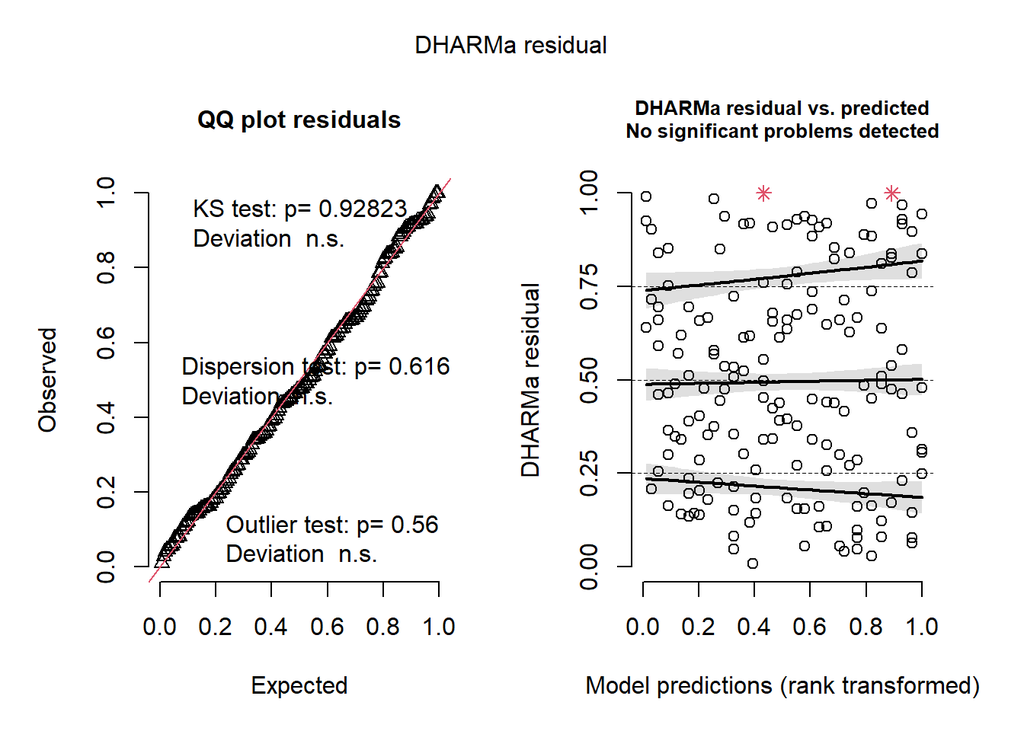

```r
coast.abnd.sim.res <- simulateResiduals(coast.total.abnd.model5) # simulate the residuals using DHARMa package for model diagnostics
plot(coast.abnd.sim.res) # No significant problems detected
```

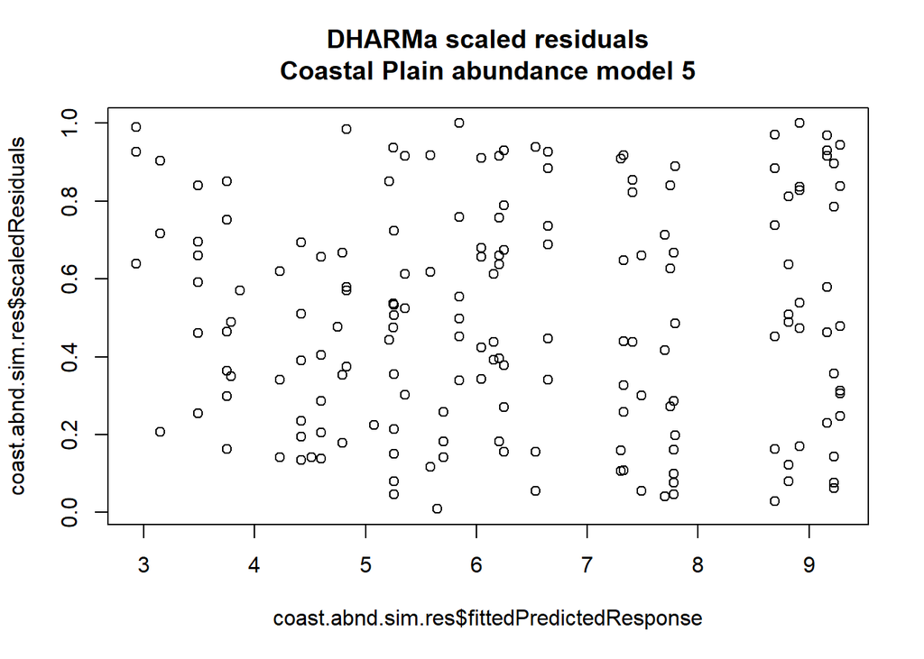

```r
plot(coast.abnd.sim.res$fittedPredictedResponse, coast.abnd.sim.res$scaledResiduals, main = 'DHARMa scaled residuals\nCoastal Plain abundance model 5')
```

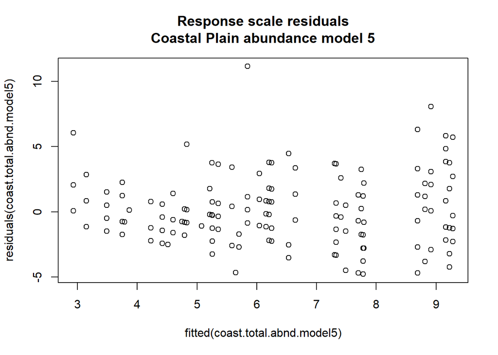

```r
plot(fitted(coast.total.abnd.model5), residuals(coast.total.abnd.model5), main = 'Response scale residuals\nCoastal Plain abundance model 5')
```

There are no clear patterns/issues with the model fit. Back up all models, create a table comparing their AIC and BIC scores and keep only the selected model:

```r
# for (model in c(ls()[grep('*coast.total.abnd.model', ls())])){
#   capture.output(cat(model), cat('\n=========\n'), summary(get(model)), cat('\n=========\n'),
#                  file = '../output/Coastal Dunes - total abundance model selection.txt', append = T)
# }

# save(list = ls()[grep('*coast.total.abnd.model', ls())], file = '../output/Coast Dunes - total abundance models.Rdata')
# capture.output(cat('The best fitting model for species richness in the Coastal Dunes is coast.total.abnd.model5.'),
#                summary(coast.total.abnd.model5),
#                testDispersion(coast.abnd.sim.res, alternative = 'less', plot = F),
#                testDispersion(coast.abnd.sim.res, alternative = 'greater', plot = F),
#                testZeroInflation(coast.abnd.sim.res, alternative = 'greater', plot = F),
#                testZeroInflation(coast.abnd.sim.res, alternative = 'less', plot = F),
#                file = '../output/Coastal Dunes total abundance - best fitting model.txt', append = F)

# Create a table comparing total abundance models:
total.abnd.comparison <- data.table(unit = '', model = '',  data = '', family = '', formula = '', no.of.preds = 0, AIC = 0, BIC = 0) # Create a data.table to be filled by a loop
total.abnd.comparison <- total.abnd.comparison[AIC > 0] # empty the data.table

for(model in ls()[grep('*coast.total.abnd.model.', ls())]){
  total.abnd.comparison <- rbind(total.abnd.comparison,
                              data.table(unit = 'Coast Sands', model = model,
                                         no.of.preds = length(attr(get(model)$modelInfo$terms$cond$fixed, 'term.labels')),
                                         AIC = AIC(get(model)), BIC = BIC(get(model)),
                                         data = as.character(get(model)$call$data),
                                         family = as.character(get(model)$call$family),
                                         formula = as.character(get(model)$call$formula)))
}
total.abnd.comparison <- total.abnd.comparison[!(formula %like% '~' | formula %like% 'total.abundance')] # remove redundant rows
total.abnd.comparison <- unique(total.abnd.comparison)
setorder(total.abnd.comparison, unit, AIC)  # Sort by AIC (ascending)
total.abnd.comparison[unit == 'Coast Sands'] # View the table
```

```
##           unit                               model   data  family
##         <char>                              <char> <char>  <char>
## 1: Coast Sands             coast.total.abnd.model3  coast poisson
## 2: Coast Sands             coast.total.abnd.model4  coast poisson
## 3: Coast Sands             coast.total.abnd.model2  coast poisson
## 4: Coast Sands             coast.total.abnd.model5  coast poisson
## 5: Coast Sands coast.total.abnd.model.full.Poisson  coast poisson
## 6: Coast Sands             coast.total.abnd.model1  coast poisson
##                                                                                                               formula
##                                                                                                                <char>
## 1:                                    settlements + year.count + dunes + sin.dist.21.June + cos.dist.21.June + Region
## 2:                                                 settlements + dunes + sin.dist.21.June + cos.dist.21.June + Region
## 3:                                    settlements + year.count * dunes + sin.dist.21.June + cos.dist.21.June + Region
## 4:                                                         settlements + sin.dist.21.June + cos.dist.21.June + Region
## 5: year.count * settlements + year.count * dunes + dunes * settlements + sin.dist.21.June + cos.dist.21.June + Region
## 6:                       year.count * settlements + year.count * dunes + sin.dist.21.June + cos.dist.21.June + Region
##    no.of.preds      AIC      BIC
##          <num>    <num>    <num>
## 1:           6 783.8312 805.7818
## 2:           5 784.2577 803.0725
## 3:           7 784.3607 809.4471
## 4:           4 785.7615 801.4404
## 5:           9 786.0107 814.2329
## 6:           8 786.0107 814.2329
```

```r
rm(list = setdiff(ls()[grep('*coast.total.abnd.model', ls())], c('coast.total.abnd.model5'))) # Clean up
```

Since the chosen model includes a difference between near and far plots, we will try to predict its magnitude (without extrapolating):

```r
# Coastal Sands - predict reptile total abundance----
summary(coast.total.abnd.model5)
```

```
##  Family: poisson  ( log )
## Formula:
## total.abundance ~ settlements + sin.dist.21.June + cos.dist.21.June +
##     Region
## Data: coast
##
##      AIC      BIC   logLik deviance df.resid
##    785.8    801.4   -387.9    775.8      165
##
##
## Conditional model:
##                  Estimate Std. Error z value Pr(>|z|)
## (Intercept)       0.71033    0.33910   2.095  0.03619 *
## settlementsNear  -0.17437    0.06680  -2.610  0.00905 **
## sin.dist.21.June  0.97221    0.34610   2.809  0.00497 **
## cos.dist.21.June  0.83798    0.11415   7.341 2.12e-13 ***
## RegionSouth       0.23708    0.08168   2.903  0.00370 **
## ---
## Signif. codes:  0 '***' 0.001 '**' 0.01 '*' 0.05 '.' 0.1 ' ' 1
```

```r
# Predict by the mean observed values
reptiles[, sort(unique(unit))]
```

```
## [1] Coastal Plain Sands
## [2] Inland Sands
## [3] Loess Covered Areas in the Northern Negev
## [4] Mediterranean-Desert Transition Zone
## [5] Planted Conifer Forests
## 5 Levels: Coastal Plain Sands ... Planted Conifer Forests
```

```r
quantile(reptiles[unit == 'Coastal Plain Sands', .(day.of.year = unique(yday(date))), by = survey_ID][, day.of.year])
```

```
##   0%  25%  50%  75% 100%
##  202  232  263  293  293
```

```r
# Dates vary from 202 (July 21st) to 293 (October 20th) with a median of 263 (September 20th)

## Calculate the mean radian angle of the date and time of sampling and use this for model fit to predict trends
# Create a table to be filled by a loop with predictor values to be used for predictions
reptiles[unit %like% 'Coast', .(no.of.surveys = uniqueN(survey_ID)), keyby = yday(Date)] # day 279 is the most common date
```

```
## Key: <yday>
##      yday no.of.surveys
##     <int>         <int>
##  1:   205             9
##  2:   215             9
##  3:   218             9
##  4:   225             9
##  5:   231             9
##  6:   237             9
##  7:   241             9
##  8:   252             8
##  9:   253             9
## 10:   259             6
## 11:   265             9
## 12:   269             9
## 13:   271             6
## 14:   273             6
## 15:   274             4
## 16:   275             2
## 17:   278             7
## 18:   279            14
## 19:   286             6
## 20:   287             3
## 21:   288             9
## 22:   296             9
##      yday no.of.surveys
```

```r
yday(as.Date('2021-10-06')) # October 6th is day 279 in non-leap years
```

```
## [1] 279
```

```r
reptiles[unit %like% 'Coast', .(no.of.surveys = uniqueN(survey_ID)), keyby = month(Date)] # August to October are equally the most common months
```

```
## Key: <month>
##    month no.of.surveys
##    <int>         <int>
## 1:     7             9
## 2:     8            54
## 3:     9            53
## 4:    10            54
```

```r
reptiles[unit %like% 'Coast', .(no.of.surveys = uniqueN(survey_ID)), keyby = round(ITime)] # 16:00 to 18:00 is the most common hours
```

```
## Key: <round>
##        round no.of.surveys
##      <ITime>         <int>
##  1: 06:00:00            13
##  2: 07:00:00            19
##  3: 08:00:00            12
##  4: 09:00:00             7
##  5: 10:00:00            10
##  6: 11:00:00             2
##  7: 14:00:00             1
##  8: 15:00:00            10
##  9: 16:00:00            28
## 10: 17:00:00            29
## 11: 18:00:00            27
## 12: 19:00:00            11
## 13: 20:00:00             1
```

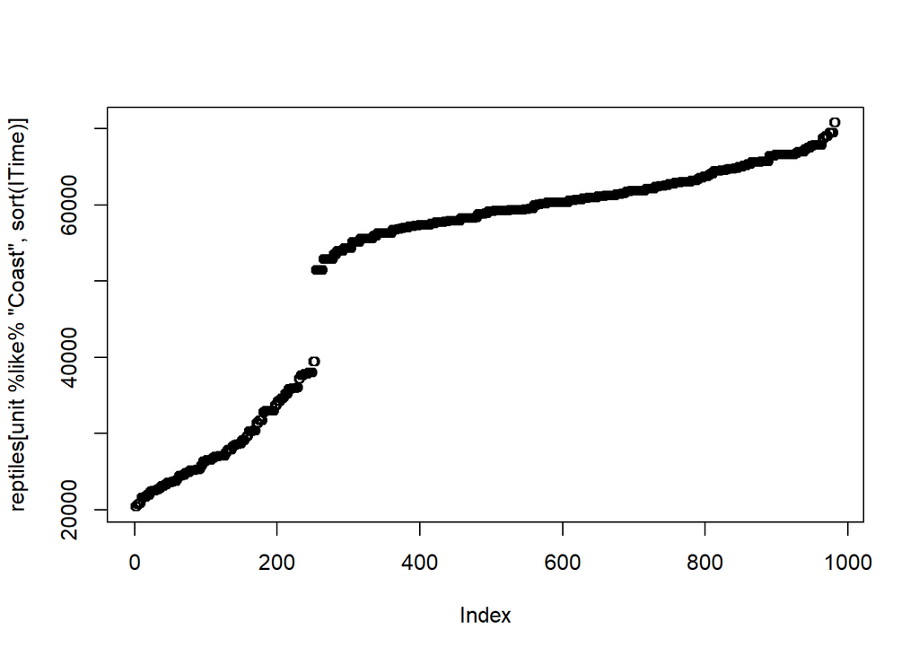

```r
plot(reptiles[unit %like% 'Coast', sort(ITime)])
```

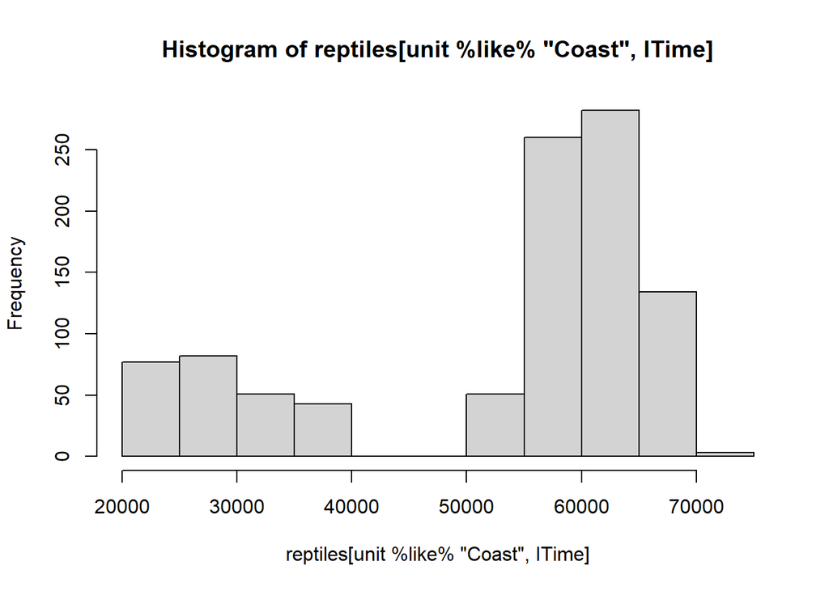

```r
hist(reptiles[unit %like% 'Coast', ITime])
```

```r
reptiles[unit %like% 'Coast', .(no.of.surveys = uniqueN(survey_ID)), keyby = ITime] # this indeed seems to be the case...
```

```
## Key: <ITime>
##         ITime no.of.surveys
##       <ITime>         <int>
##   1: 05:40:00             1
##   2: 05:45:00             1
##   3: 05:48:00             1
##   4: 06:00:00             1
##   5: 06:01:00             1
##  ---
## 147: 18:52:00             1
## 148: 19:06:00             1
## 149: 19:10:00             1
## 150: 19:18:00             1
## 151: 19:40:00             1
```

```r
# Plot the model seasonal pattern
reptiles[unit %like% 'Coast', unique(year)]
```

```
## [1] 2014 2015 2017 2019 2021
```

```r
coast.total.abnd.sea <- data.table(expand.grid(Date = seq.Date(as.Date('2014-01-01'), as.Date('2021-12-31'), by = 1), settlements = coast[, unique(settlements)], Region = c('North', 'South')))
coast.total.abnd.sea[, ':=' (year = year(Date),
                                          dist.21.June = ifelse(yday(Date) < 354,
                                                                Date - as.Date(paste(year(Date), 6, 21, sep = '-')),
                                                                Date - as.Date(paste(year(Date) + 1, 6, 21, sep = '-'))))]
coast.total.abnd.sea <- coast.total.abnd.sea[year %in% reptiles[unit %like% 'Coast', unique(year)]]
coast.total.abnd.sea[, ':=' (dist.21.June.radians = dist.21.June * pi / 182.5, # Convert to radians (multiply by pi and divide by half the number of days in a year), one harmonic
                                          dist.21.June.radians.2h = 2*dist.21.June * pi / 182.5)]
setorder(coast.total.abnd.sea, Date, dist.21.June.radians)
coast.total.abnd.sea[, ':=' (year.count = year - min(year))]
coast.total.abnd.sea[, ':=' (sin.dist.21.June = sin(dist.21.June.radians), cos.dist.21.June = cos(dist.21.June.radians))] # Calculate the sin and cosine of the distance from June 21st
coast.total.abnd.sea
```

```
##             Date settlements Region  year dist.21.June dist.21.June.radians
##           <Date>      <fctr> <fctr> <int>        <num>                <num>
##    1: 2014-01-01         Far  North  2014         -171            -2.943629
##    2: 2014-01-01        Near  North  2014         -171            -2.943629
##    3: 2014-01-01         Far  South  2014         -171            -2.943629
##    4: 2014-01-01        Near  South  2014         -171            -2.943629
##    5: 2014-01-02         Far  North  2014         -170            -2.926415
##   ---
## 7296: 2021-12-30        Near  South  2021         -173            -2.978058
## 7297: 2021-12-31         Far  North  2021         -172            -2.960843
## 7298: 2021-12-31        Near  North  2021         -172            -2.960843
## 7299: 2021-12-31         Far  South  2021         -172            -2.960843
## 7300: 2021-12-31        Near  South  2021         -172            -2.960843
##       dist.21.June.radians.2h year.count sin.dist.21.June cos.dist.21.June
##                         <num>      <int>            <num>            <num>
##    1:               -5.887259          0       -0.1966729       -0.9804692
##    2:               -5.887259          0       -0.1966729       -0.9804692
##    3:               -5.887259          0       -0.1966729       -0.9804692
##    4:               -5.887259          0       -0.1966729       -0.9804692
##    5:               -5.852830          0       -0.2135209       -0.9769385
##   ---
## 7296:               -5.956115          7       -0.1628070       -0.9866579
## 7297:               -5.921687          7       -0.1797666       -0.9837093
## 7298:               -5.921687          7       -0.1797666       -0.9837093
## 7299:               -5.921687          7       -0.1797666       -0.9837093
## 7300:               -5.921687          7       -0.1797666       -0.9837093
```

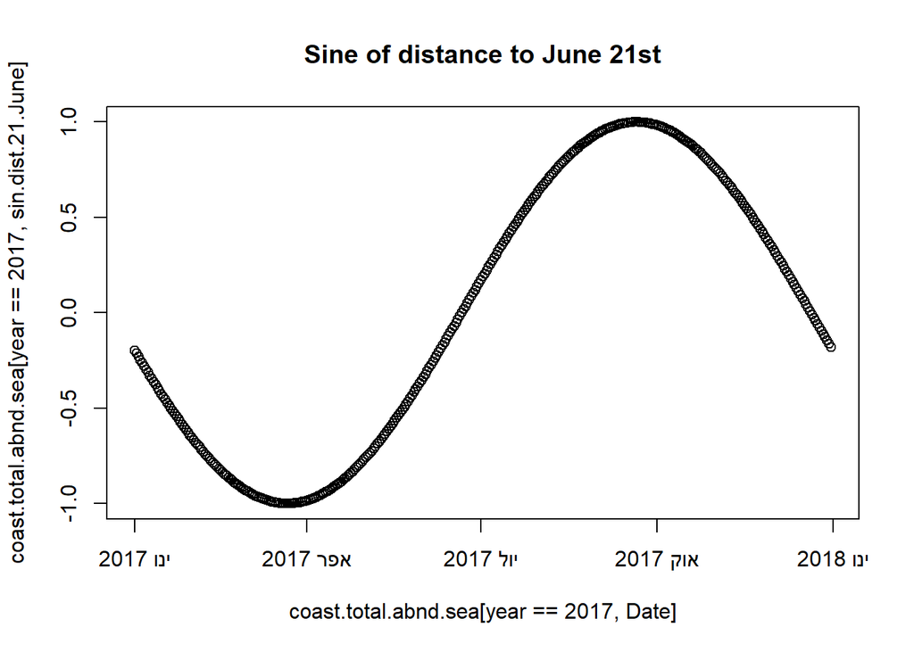

```r
plot(coast.total.abnd.sea[year == 2017, Date], coast.total.abnd.sea[year == 2017,sin.dist.21.June],
     main = 'Sine of distance to June 21st') # sanity check - should be a wave
```

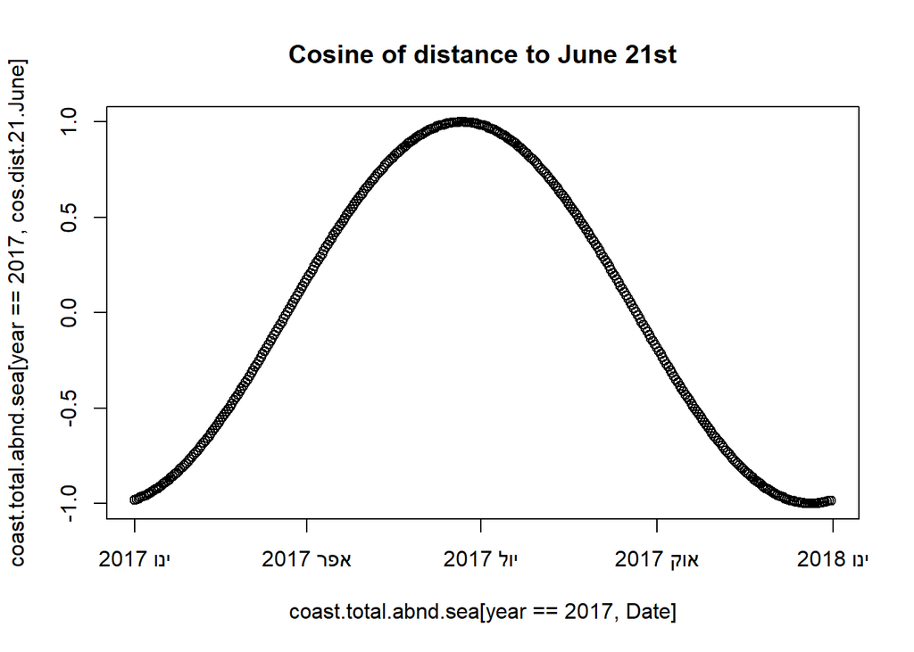

```r
plot(coast.total.abnd.sea[year == 2017, Date], coast.total.abnd.sea[year == 2017,cos.dist.21.June],
     main = 'Cosine of distance to June 21st') # sanity check - should be a wave
```

```r
bla <- predict(coast.total.abnd.model5, newdata = coast.total.abnd.sea, type = 'response', se.fit = T)
coast.total.abnd.sea[, ':=' (predicted.abnd = bla$fit, predicted.abnd.se = bla$se.fit)]
coast.total.abnd.sea[month(Date) %in% 9, .(mean.predicted.abnd = mean(predicted.abnd)), keyby = .(year)]
```

```
## Key: <year>
##     year mean.predicted.abnd
##    <int>               <num>
## 1:  2014            5.957572
## 2:  2015            5.957572
## 3:  2017            5.957572
## 4:  2019            5.957572
## 5:  2021            5.957572
```

```r
coast.total.abnd.sea
```

```
## Index: <year>
##             Date settlements Region  year dist.21.June dist.21.June.radians
##           <Date>      <fctr> <fctr> <int>        <num>                <num>
##    1: 2014-01-01         Far  North  2014         -171            -2.943629
##    2: 2014-01-01        Near  North  2014         -171            -2.943629
##    3: 2014-01-01         Far  South  2014         -171            -2.943629
##    4: 2014-01-01        Near  South  2014         -171            -2.943629
##    5: 2014-01-02         Far  North  2014         -170            -2.926415
##   ---
## 7296: 2021-12-30        Near  South  2021         -173            -2.978058
## 7297: 2021-12-31         Far  North  2021         -172            -2.960843
## 7298: 2021-12-31        Near  North  2021         -172            -2.960843
## 7299: 2021-12-31         Far  South  2021         -172            -2.960843
## 7300: 2021-12-31        Near  South  2021         -172            -2.960843
##       dist.21.June.radians.2h year.count sin.dist.21.June cos.dist.21.June
```

[output cut: 25 more lines]

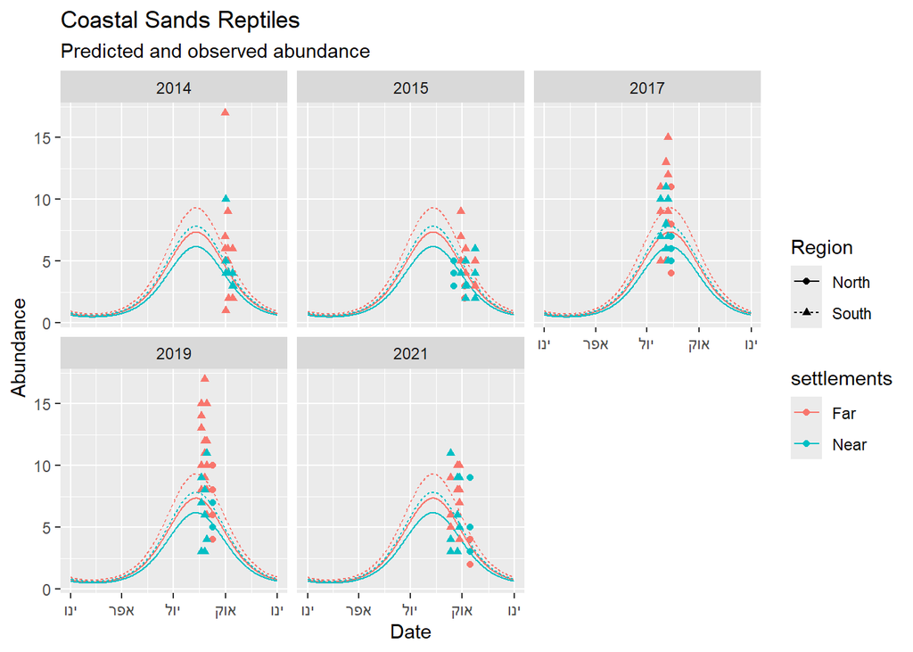

```r
# plot the seasonal predictions
ggplot(data = coast.total.abnd.sea, aes(x = as.Date(paste(2017, month(Date), mday(Date), sep = '-')), y = predicted.abnd, color = settlements, linetype = Region, shape = Region)) + geom_line() +
  geom_point(data = reptiles[unit %like% 'Coast', .(total.abnd = sum(count_individuals, na.rm = T)),
                             keyby = .(Region = ifelse(site == 'Caesarea', 'North', 'South'), settlements, survey_ID, year(Date), as.Date(paste(2017, month(Date), mday(Date), sep = '-')))],
             aes(x = as.Date, y = total.abnd)) + labs(x = 'Date', y = 'Abundance', title = 'Coastal Sands Reptiles',
                                                      subtitle = 'Predicted and observed abundance') +
  facet_wrap(. ~ year) + scale_x_date(date_labels = '%b')
```

```r
# Create a data.table for predictions
coast.total.abnd.fit.data <- data.table(expand.grid(Date = as.Date('2017-08-15'), settlements = c('Far', 'Near'), Region = c('North','South')))
coast.total.abnd.fit.data[, ':=' (dist.21.June = ifelse(yday(Date) < 354,
                                                               Date - as.Date(paste(year(Date), 6, 21, sep = '-')),
                                                               Date - as.Date(paste(year(Date) + 1, 6, 21, sep = '-'))))]
coast.total.abnd.fit.data[, ':=' (dist.21.June.radians = dist.21.June * pi / 182.5, # Convert to radians (multiply by pi and divide by half the number of days in a year), one harmonic
                                         dist.21.June.radians.2h = 2*dist.21.June * pi / 182.5)]
setorder(coast.total.abnd.fit.data, dist.21.June.radians)
coast.total.abnd.fit.data # seems ok
```

```
##          Date settlements Region dist.21.June dist.21.June.radians
##        <Date>      <fctr> <fctr>        <num>                <num>
## 1: 2017-08-15         Far  North           55            0.9467813
## 2: 2017-08-15        Near  North           55            0.9467813
## 3: 2017-08-15         Far  South           55            0.9467813
## 4: 2017-08-15        Near  South           55            0.9467813
##    dist.21.June.radians.2h
##                      <num>
## 1:                1.893563
## 2:                1.893563
## 3:                1.893563
## 4:                1.893563
```

```r
coast.total.abnd.fit.data[, ':=' (sin.dist.21.June = sin(dist.21.June.radians), cos.dist.21.June = cos(dist.21.June.radians))] # Calculate the sin and cosine of the distance from June 21st
coast.total.abnd.fit.data
```

```
##          Date settlements Region dist.21.June dist.21.June.radians
##        <Date>      <fctr> <fctr>        <num>                <num>
## 1: 2017-08-15         Far  North           55            0.9467813
## 2: 2017-08-15        Near  North           55            0.9467813
## 3: 2017-08-15         Far  South           55            0.9467813
## 4: 2017-08-15        Near  South           55            0.9467813
##    dist.21.June.radians.2h sin.dist.21.June cos.dist.21.June
##                      <num>            <num>            <num>
## 1:                1.893563        0.8115391        0.5842982
## 2:                1.893563        0.8115391        0.5842982
## 3:                1.893563        0.8115391        0.5842982
## 4:                1.893563        0.8115391        0.5842982
```

```r
bla <- predict(coast.total.abnd.model5, newdata = coast.total.abnd.fit.data, type = 'response', se.fit = T)
coast.total.abnd.fit.data[, ':=' (predicted.abnd = bla$fit, predicted.abnd.se = bla$se.fit)]
coast.total.abnd.fit.data[, .(settlements, predicted.abnd, predicted.abnd.se)] #
```

```
##    settlements predicted.abnd predicted.abnd.se
##         <fctr>          <num>             <num>
## 1:         Far       7.307843         0.5965563
## 2:        Near       6.138477         0.5688499
## 3:         Far       9.263016         0.4454478
## 4:        Near       7.780793         0.5001950
```

```r
coast.total.abnd.fit.data # Now the predictions finally make sense!
```

```
##          Date settlements Region dist.21.June dist.21.June.radians
##        <Date>      <fctr> <fctr>        <num>                <num>
## 1: 2017-08-15         Far  North           55            0.9467813
## 2: 2017-08-15        Near  North           55            0.9467813
## 3: 2017-08-15         Far  South           55            0.9467813
## 4: 2017-08-15        Near  South           55            0.9467813
##    dist.21.June.radians.2h sin.dist.21.June cos.dist.21.June predicted.abnd
##                      <num>            <num>            <num>          <num>
## 1:                1.893563        0.8115391        0.5842982       7.307843
## 2:                1.893563        0.8115391        0.5842982       6.138477
## 3:                1.893563        0.8115391        0.5842982       9.263016
## 4:                1.893563        0.8115391        0.5842982       7.780793
##    predicted.abnd.se
##                <num>
## 1:         0.5965563
## 2:         0.5688499
## 3:         0.4454478
## 4:         0.5001950
```

```r
coast.total.abnd.pred <- melt(unique(coast.total.abnd.fit.data[, .(settlements, Region, predicted.abnd)]),
                                     id.vars = c('settlements', 'Region'), variable.name = 'quality', value.name = 'predicted.abnd')
setorder(coast.total.abnd.pred, settlements, Region)
coast.total.abnd.pred # seems ok
```

```
##    settlements Region        quality predicted.abnd
##         <fctr> <fctr>         <fctr>          <num>
## 1:         Far  North predicted.abnd       7.307843
## 2:         Far  South predicted.abnd       9.263016
## 3:        Near  North predicted.abnd       6.138477
## 4:        Near  South predicted.abnd       7.780793
```

Calculate the mean abundance in Near and Far plots, and calculate the percent difference between the rounded values:

```r
coast.total.abnd.pred[, .(mean.pred.abnd = round(mean(predicted.abnd), 1)), keyby = settlements]
```

```
## Key: <settlements>
##    settlements mean.pred.abnd
##         <fctr>          <num>
## 1:         Far            8.3
## 2:        Near            7.0
```

```r
coast.total.abnd.pred[, .(mean.pred.abnd = round(mean(predicted.abnd), 1)), keyby = settlements][, max(mean.pred.abnd)] / coast.total.abnd.pred[, .(mean.pred.abnd = round(mean(predicted.abnd), 1)), keyby = settlements][, min(mean.pred.abnd)] - 1
```

```
## [1] 0.1857143
```

Hence, the mean predicted abundance is 8.3 reptiles in the Far plots compared to 7.0 reptiles in the Near plots (18.6% difference).

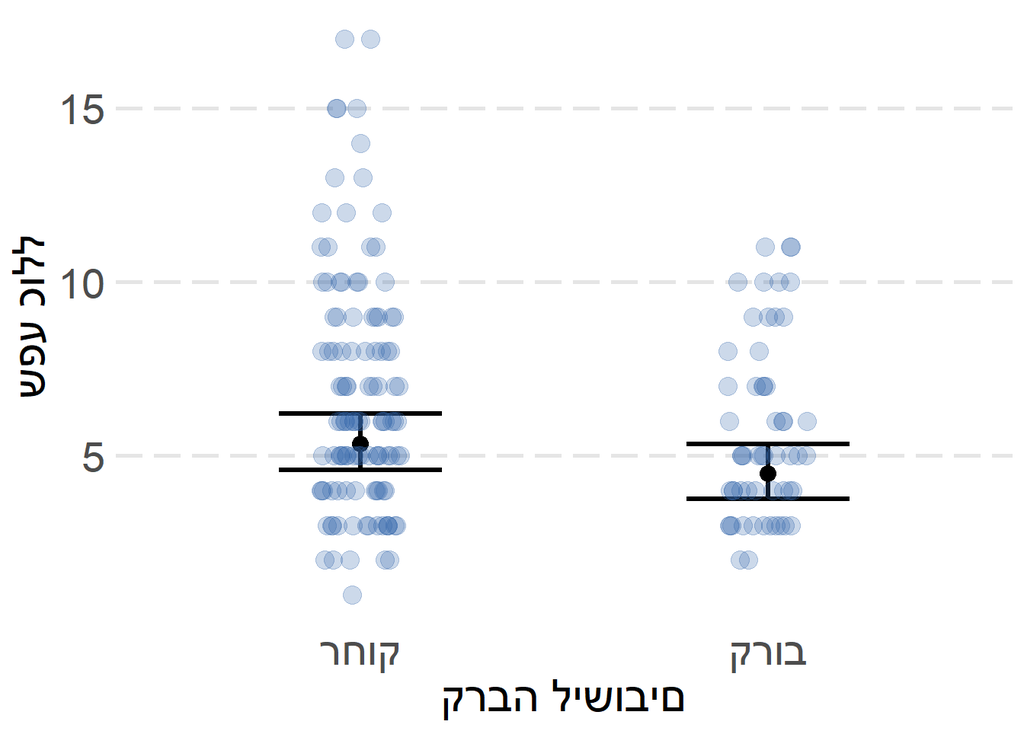

```r
# Effect plot of annual trend
coast.abnd.trend.plot <- effect_plot(model = coast.total.abnd.model5, pred = settlements, data = coast,  colors = "Qual1",point.size = 4,
                                                   line.colors = 'black', point.alpha = 0.25, interval = T, plot.points = T, partial.residuals = F,
                                                   jitter = c(0.1,0), int.type = 'confidence') +
  theme_minimal() + labs(y = strReverse('שפע כולל'), x = strReverse('קרבה לישובים')) +
  scale_x_discrete(labels = c(strReverse('רחוק'),
                              strReverse('קרוב'))) +
  theme(plot.title = element_text(hjust = 0.5), plot.subtitle = element_text(hjust = 0.5), legend.position = 'bottom',
        text = element_text(family = fontname, size = fontsize), axis.text = element_text(size = fontsize - 1),
        panel.grid.major.y = element_line(color = 'grey90', linetype = 5, linewidth = 1),
        panel.grid.minor = element_blank(), panel.grid.major.x = element_blank(), panel.grid.minor.x = element_blank())
coast.abnd.trend.plot$layers[[2]]$geom_params$width <- 0.4
coast.abnd.trend.plot
```

```r
Cairo::Cairo(file = '../output/Coastal Plain total abundance model5 effect plot - temporal trend.pdf', width = pdf_width, height = pdf_width*pdf_aspect_ratio,
             type = "PDF", units = "mm")
print(coast.abnd.trend.plot)
dev.off()
```

## Inland Sands

### Inland sands species richness

Next, species richness. Start with data visualization:

```r
# The relevant predictors are distance to settlement, dunes, and temporal trend
# Plot species richness
inland.sands <- alpha.div[unit == 'Inland Sands'] # subset the inland sands
str(inland.sands)
```

```
## Classes 'data.table' and 'data.frame':   72 obs. of  23 variables:
##  $ unit               : Factor w/ 5 levels "Coastal Plain Sands",..: 2 2 2 2 2 2 2 2 2 2 ...
##  $ year               : num  2017 2017 2017 2017 2017 ...
##  $ campaign           : Factor w/ 5 levels "T0","T1","T2",..: 3 3 3 3 3 3 3 3 3 3 ...
##  $ subunit            : Factor w/ 3 levels "Carmel","Galilee",..: NA NA NA NA NA NA NA NA NA NA ...
##  $ site               : Factor w/ 35 levels "Aderet","Amatzia",..: 6 6 6 6 6 6 6 6 6 6 ...
##  $ point_name         : Factor w/ 281 levels "Aderet 31.67144877_34.9880248",..: 36 37 38 39 40 41 43 44 45 46 ...
##  $ survey_ID          : Factor w/ 691 levels "T0_Aderet 31.67867469_34.98154177",..: 292 293 294 295 296 297 298 299 300 301 ...
##  $ Date               : Date, format: "2017-06-14" "2017-06-26" ...
##  $ sin.dist.21.June   : num  -0.12 0.086 0.086 0.086 0.086 ...
##  $ cos.dist.21.June   : num  0.993 0.996 0.996 0.996 0.996 ...
##  $ sin.dist.noon      : num  -0.903 -0.981 -0.906 -0.95 -0.989 ...
##  $ cos.dist.noon      : num  0.431 -0.195 0.423 0.313 -0.148 ...
##  $ settlements        : Factor w/ 2 levels "Far","Near": NA NA NA NA NA NA NA NA NA NA ...
##  $ agriculture        : Factor w/ 2 levels "Far","Near": 1 1 1 1 1 1 2 2 2 2 ...
##  $ dunes              : Factor w/ 2 levels "semi-shifting",..: 1 1 1 2 2 2 1 1 1 2 ...
##  $ habitat            : Factor w/ 3 levels "bedouin agriculture",..: NA NA NA NA NA NA NA NA NA NA ...
##  $ mean.lon           : num  34.5 34.4 34.4 34.4 34.4 ...
##  $ mean.lat           : num  30.9 31 30.9 30.9 31 ...
##  $ species.richness   : num  4 6 6 7 6 5 8 3 6 5 ...
##  $ total.abundance    : num  10 6 15 12 10 6 8 8 10 6 ...
##  $ geom.mean.abundance: num  1.63 1 1.78 1.47 1.52 ...
##  $ year.count         : num  0 0 0 0 0 0 0 0 0 0 ...
##  $ year.fct           : Factor w/ 8 levels "2014","2015",..: 3 3 3 3 3 3 3 3 3 3 ...
##  - attr(*, "sorted")= chr "unit"
##  - attr(*, ".internal.selfref")=<externalptr>
```

```r
inland.sands[is.na(agriculture) | is.na(dunes)] # no missing variables
```

```
## Key: <unit>
## Empty data.table (0 rows and 23 cols): unit,year,campaign,subunit,site,point_name...
```

```r
inland.sands[, .(no.of.surveys = uniqueN(survey_ID)), keyby = .(campaign, year, site, agriculture, dunes)] # Always 3 surveys per site-agri-dunes
```

```
## Key: <campaign, year, site, agriculture, dunes>
##     campaign  year        site agriculture         dunes no.of.surveys
##       <fctr> <num>      <fctr>      <fctr>        <fctr>         <int>
##  1:       T2  2017  Beer Milka         Far semi-shifting             3
##  2:       T2  2017  Beer Milka         Far      shifting             3
##  3:       T2  2017  Beer Milka        Near semi-shifting             3
##  4:       T2  2017  Beer Milka        Near      shifting             3
##  5:       T2  2017      Secher         Far semi-shifting             3
##  6:       T2  2017      Secher         Far      shifting             3
##  7:       T2  2017 Shunra East         Far semi-shifting             3
##  8:       T2  2017 Shunra East         Far      shifting             3
##  9:       T3  2019  Beer Milka         Far semi-shifting             3
## 10:       T3  2019  Beer Milka         Far      shifting             3
## 11:       T3  2019  Beer Milka        Near semi-shifting             3
## 12:       T3  2019  Beer Milka        Near      shifting             3
## 13:       T3  2019      Secher         Far semi-shifting             3
## 14:       T3  2019      Secher         Far      shifting             3
## 15:       T3  2019 Shunra East         Far semi-shifting             3
## 16:       T3  2019 Shunra East         Far      shifting             3
## 17:       T4  2021  Beer Milka         Far semi-shifting             3
## 18:       T4  2021  Beer Milka         Far      shifting             3
## 19:       T4  2021  Beer Milka        Near semi-shifting             3
## 20:       T4  2021  Beer Milka        Near      shifting             3
## 21:       T4  2021      Secher         Far semi-shifting             3
## 22:       T4  2021      Secher         Far      shifting             3
## 23:       T4  2021 Shunra East         Far semi-shifting             3
## 24:       T4  2021 Shunra East         Far      shifting             3
##     campaign  year        site agriculture         dunes no.of.surveys
```

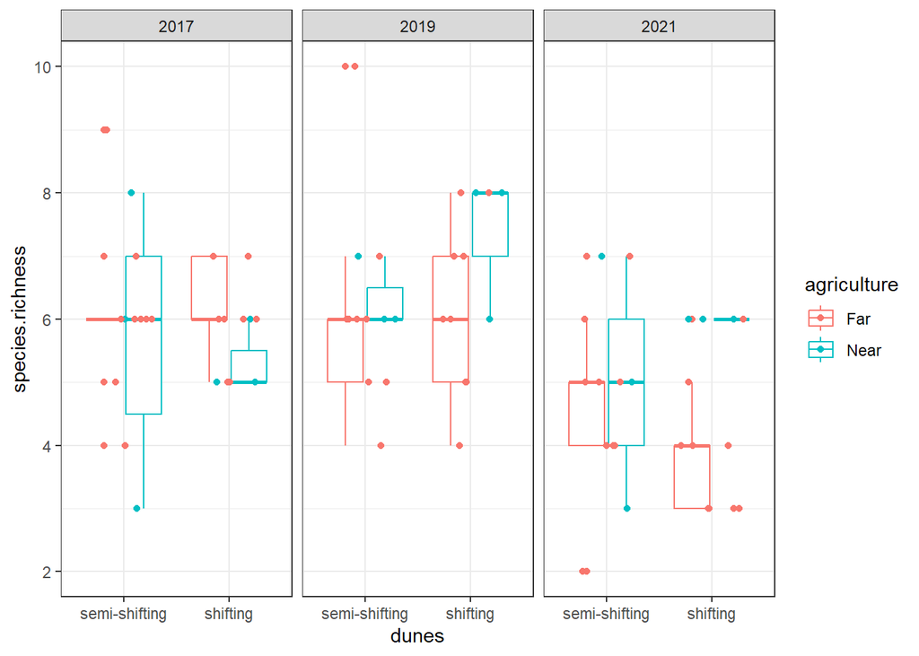

```r
ggplot(data = inland.sands, aes(x = dunes, color = agriculture, y = species.richness)) + geom_boxplot() +
  geom_jitter(height = 0, width = 0.3) +  facet_wrap(. ~ year) + theme_bw() # 2021 seem worse than 2017-2019
```

Species richness model selection:

```r
## Inland sands species richness model selection----
# Full model, Poisson response
inland.sands.sp.rich.model.full.Poisson <- glmmTMB(species.richness ~ agriculture * dunes + sin.dist.21.June + cos.dist.21.June + site,
                                            family = 'poisson', data = inland.sands)
summary(inland.sands.sp.rich.model.full.Poisson) # AIC = 296.8; BIC = 317.3. Only cosine seasonality is significant
```

```
##  Family: poisson  ( log )
## Formula:
## species.richness ~ agriculture * dunes + sin.dist.21.June + cos.dist.21.June +
##     site
## Data: inland.sands
##
##      AIC      BIC   logLik deviance df.resid
##    295.6    313.8   -139.8    279.6       64
##
##
## Conditional model:
##                               Estimate Std. Error z value Pr(>|z|)
## (Intercept)                   -0.23149    1.00393  -0.231   0.8176
## agricultureNear               -0.09090    0.18062  -0.503   0.6148
## dunesshifting                 -0.04027    0.11588  -0.348   0.7282
## sin.dist.21.June               0.61937    0.42424   1.460   0.1443
## cos.dist.21.June               2.02175    0.96692   2.091   0.0365 *
## siteSecher                    -0.00733    0.15070  -0.049   0.9612
## siteShunra East               -0.09392    0.14153  -0.664   0.5069
## agricultureNear:dunesshifting  0.18502    0.22731   0.814   0.4157
## ---
## Signif. codes:  0 '***' 0.001 '**' 0.01 '*' 0.05 '.' 0.1 ' ' 1
```

```r
cat('PHI = ')
```

```
## PHI =
```

```r
deviance(inland.sands.sp.rich.model.full.Poisson)/df.residual(inland.sands.sp.rich.model.full.Poisson)
```

```
## [1] 0.3671671
```

```r
drop1(inland.sands.sp.rich.model.full.Poisson) # Should omit sine distance to noon
```

```
## Single term deletions
##
## Model:
## species.richness ~ agriculture * dunes + sin.dist.21.June + cos.dist.21.June +
##     site
##                   Df    AIC
## <none>               295.60
## sin.dist.21.June   1 295.77
## cos.dist.21.June   1 298.09
## site               2 292.09
## agriculture:dunes  1 294.26
```

PHI < 1, so we continue with Poisson. We can drop the interaction between agriculture and dunes:

```r
inland.sands.sp.rich.model1 <- glmmTMB(species.richness ~ agriculture + dunes + sin.dist.21.June + cos.dist.21.June + site, family = 'poisson', data = inland.sands)
summary(inland.sands.sp.rich.model1)
```

```
##  Family: poisson  ( log )
## Formula:
## species.richness ~ agriculture + dunes + sin.dist.21.June + cos.dist.21.June +
##     site
## Data: inland.sands
##
##      AIC      BIC   logLik deviance df.resid
##    294.3    310.2   -140.1    280.3       65
##
##
## Conditional model:
##                   Estimate Std. Error z value Pr(>|z|)
## (Intercept)      -0.160308   1.002960  -0.160    0.873
## agricultureNear   0.001854   0.138098   0.013    0.989
## dunesshifting     0.007849   0.099661   0.079    0.937
## sin.dist.21.June  0.576815   0.421979   1.367    0.172
## cos.dist.21.June  1.931970   0.963553   2.005    0.045 *
## siteSecher       -0.009585   0.150761  -0.064    0.949
## siteShunra East  -0.093688   0.141552  -0.662    0.508
## ---
## Signif. codes:  0 '***' 0.001 '**' 0.01 '*' 0.05 '.' 0.1 ' ' 1
```

```r
drop1(inland.sands.sp.rich.model1)
```

```
## Single term deletions
##
## Model:
## species.richness ~ agriculture + dunes + sin.dist.21.June + cos.dist.21.June +
##     site
##                  Df    AIC
## <none>              294.26
## agriculture       1 292.26
## dunes             1 292.26
## sin.dist.21.June  1 294.17
## cos.dist.21.June  1 296.40
## site              2 290.75
```

We can drop either agriculture or dune. Let’s try dropping dunes:

```r
inland.sands.sp.rich.model2 <- glmmTMB(species.richness ~ agriculture + sin.dist.21.June + cos.dist.21.June + site, family = 'poisson', data = inland.sands)
summary(inland.sands.sp.rich.model2)
```

```
##  Family: poisson  ( log )
## Formula:
## species.richness ~ agriculture + sin.dist.21.June + cos.dist.21.June +
##     site
## Data: inland.sands
##
##      AIC      BIC   logLik deviance df.resid
##    292.3    305.9   -140.1    280.3       66
##
##
## Conditional model:
##                   Estimate Std. Error z value Pr(>|z|)
## (Intercept)      -0.150885   0.995932  -0.152   0.8796
## agricultureNear   0.001735   0.138089   0.013   0.9900
## sin.dist.21.June  0.574359   0.420877   1.365   0.1724
## cos.dist.21.June  1.926782   0.961459   2.004   0.0451 *
## siteSecher       -0.009715   0.150757  -0.064   0.9486
## siteShunra East  -0.093673   0.141553  -0.662   0.5081
## ---
## Signif. codes:  0 '***' 0.001 '**' 0.01 '*' 0.05 '.' 0.1 ' ' 1
```

```r
drop1(inland.sands.sp.rich.model2)
```

```
## Single term deletions
##
## Model:
## species.richness ~ agriculture + sin.dist.21.June + cos.dist.21.June +
##     site
##                  Df    AIC
## <none>              292.26
## agriculture       1 290.26
## sin.dist.21.June  1 292.17
## cos.dist.21.June  1 294.41
## site              2 288.75
```

Now let’s drop agriculture too:

```r
inland.sands.sp.rich.model3 <- glmmTMB(species.richness ~ sin.dist.21.June + cos.dist.21.June + site, family = 'poisson', data = inland.sands)
summary(inland.sands.sp.rich.model3)
```

```
##  Family: poisson  ( log )
## Formula:          species.richness ~ sin.dist.21.June + cos.dist.21.June + site
## Data: inland.sands
##
##      AIC      BIC   logLik deviance df.resid
##    290.3    301.6   -140.1    280.3       67
##
##
## Conditional model:
##                  Estimate Std. Error z value Pr(>|z|)
## (Intercept)      -0.15006    0.99381  -0.151    0.880
## sin.dist.21.June  0.57416    0.42059   1.365    0.172
## cos.dist.21.June  1.92691    0.96142   2.004    0.045 *
## siteSecher       -0.01054    0.13588  -0.078    0.938
## siteShunra East  -0.09457    0.12240  -0.773    0.440
## ---
## Signif. codes:  0 '***' 0.001 '**' 0.01 '*' 0.05 '.' 0.1 ' ' 1
```

```r
drop1(inland.sands.sp.rich.model3)
```

```
## Single term deletions
##
## Model:
## species.richness ~ sin.dist.21.June + cos.dist.21.June + site
##                  Df    AIC
## <none>              290.26
## sin.dist.21.June  1 290.17
## cos.dist.21.June  1 292.41
## site              2 286.88
```

We can drop sine seasonality:

```r
inland.sands.sp.rich.model4 <- glmmTMB(species.richness ~ cos.dist.21.June + site, family = 'poisson', data = inland.sands)
summary(inland.sands.sp.rich.model4)
```

```
##  Family: poisson  ( log )
## Formula:          species.richness ~ cos.dist.21.June + site
## Data: inland.sands
##
##      AIC      BIC   logLik deviance df.resid
##    290.2    299.3   -141.1    282.2       68
##
##
## Conditional model:
##                  Estimate Std. Error z value Pr(>|z|)
## (Intercept)       1.08590    0.40130   2.706  0.00681 **
## cos.dist.21.June  0.76014    0.43529   1.746  0.08076 .
## siteSecher       -0.03062    0.13581  -0.225  0.82163
## siteShunra East  -0.08936    0.12242  -0.730  0.46543
## ---
## Signif. codes:  0 '***' 0.001 '**' 0.01 '*' 0.05 '.' 0.1 ' ' 1
```

```r
drop1(inland.sands.sp.rich.model4)
```

```
## Single term deletions
##
## Model:
## species.richness ~ cos.dist.21.June + site
##                  Df    AIC
## <none>              290.17
## cos.dist.21.June  1 291.27
## site              2 286.71
```

We can drop also cosine seasonality and retain only site ID (because we insist on keeping it despite indications from AIC that we should drop it):

```r
inland.sands.sp.rich.model5 <- glmmTMB(species.richness ~ site, family = 'poisson', data = inland.sands)
summary(inland.sands.sp.rich.model5)
```

```
##  Family: poisson  ( log )
## Formula:          species.richness ~ site
## Data: inland.sands
##
##      AIC      BIC   logLik deviance df.resid
##    291.3    298.1   -142.6    285.3       69
##
##
## Conditional model:
##                 Estimate Std. Error z value Pr(>|z|)
## (Intercept)      1.77307    0.06868  25.816   <2e-16 ***
## siteSecher      -0.13084    0.12438  -1.052    0.293
## siteShunra East -0.05827    0.12131  -0.480    0.631
## ---
## Signif. codes:  0 '***' 0.001 '**' 0.01 '*' 0.05 '.' 0.1 ' ' 1
```

```r
drop1(inland.sands.sp.rich.model5)
```

```
## Single term deletions
##
## Model:
## species.richness ~ site
##        Df    AIC
## <none>    291.27
## site    2 288.42
```

As we refuse to drop site identity, we cannot drop any more predictors. Let’s proceed to model diagnostics:

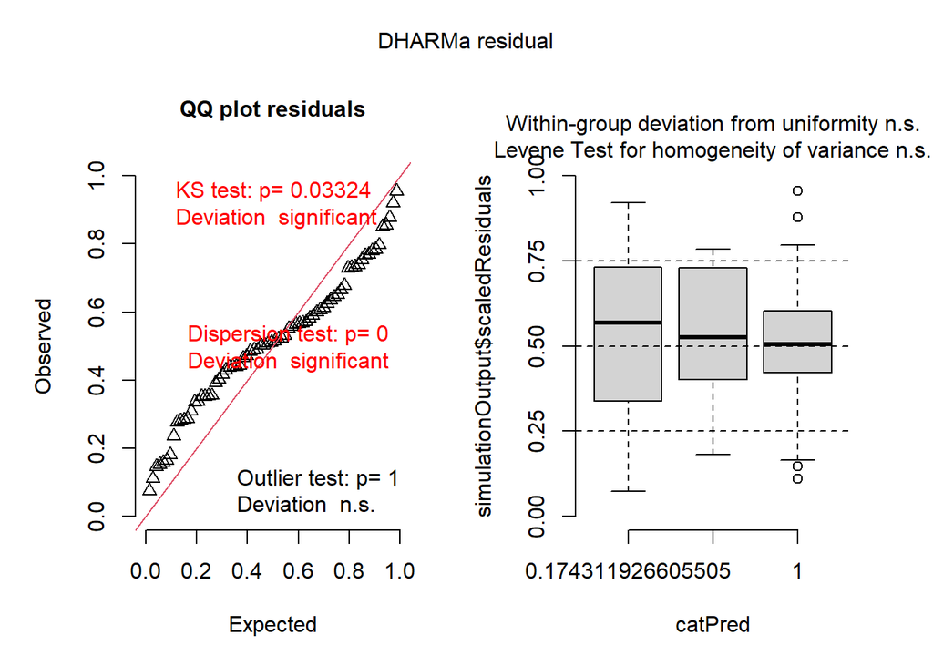

```r
# Inland sands species richness model diagnostics and back up----
inland.sands.sp.rich.sim.res <- simulateResiduals(inland.sands.sp.rich.model5) # simulate the residuals using DHARMa package for model diagnostics
plot(inland.sands.sp.rich.sim.res) # Dispersion test is significant
```

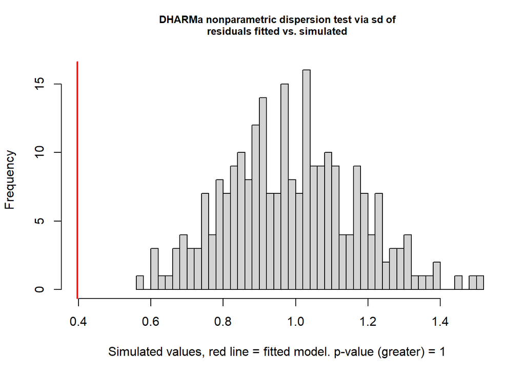

```
##
##  DHARMa nonparametric dispersion test via sd of residuals fitted vs.
##  simulated
##
## data:  simulationOutput
## dispersion = 0.40226, p-value = 1
## alternative hypothesis: greater
```

```r
testDispersion(inland.sands.sp.rich.sim.res, alternative = 'greater') # p = 1, suggesting under-dispersion
```

```r
testDispersion(inland.sands.sp.rich.sim.res, alternative = 'less', plot = F) # p < 2.2e-16 -> under-dispersion, small power
```

```
##
##  DHARMa nonparametric dispersion test via sd of residuals fitted vs.
##  simulated
##
## data:  simulationOutput
## dispersion = 0.40226, p-value < 2.2e-16
## alternative hypothesis: less
```

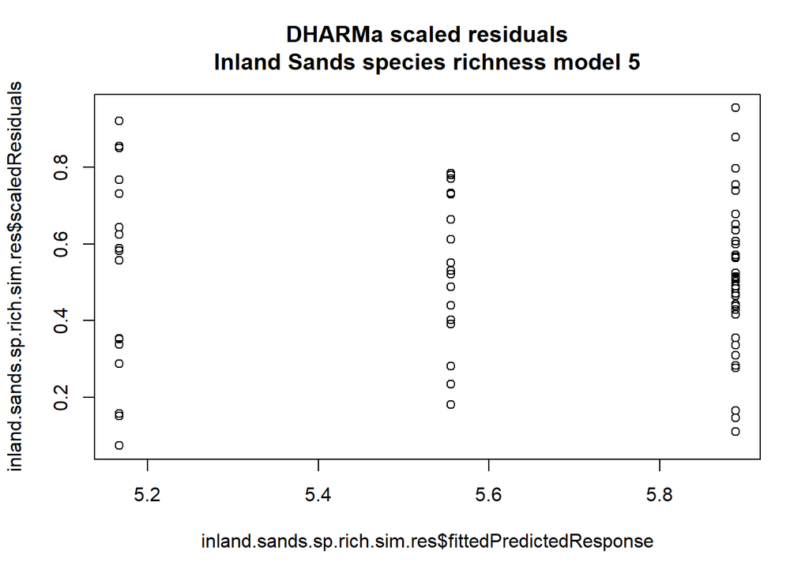

```r
plot(inland.sands.sp.rich.sim.res$fittedPredictedResponse, inland.sands.sp.rich.sim.res$scaledResiduals, main = 'DHARMa scaled residuals\nInland Sands species richness model 5')
```

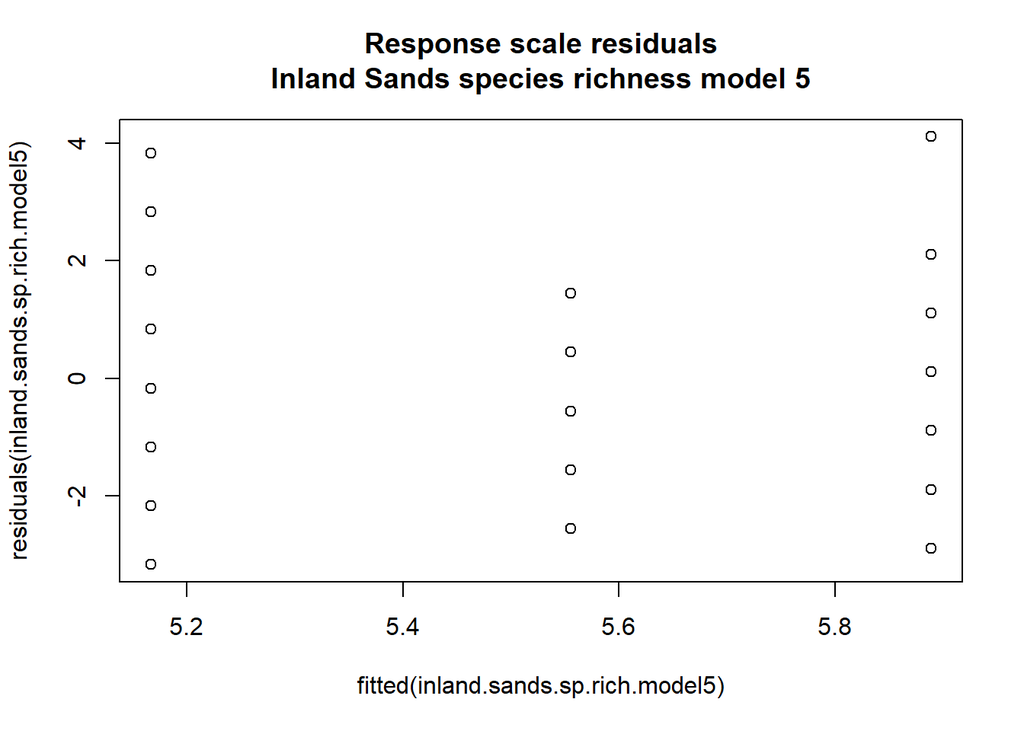

```r
plot(fitted(inland.sands.sp.rich.model5), residuals(inland.sands.sp.rich.model5), main = 'Response scale residuals\nInland Sands species richness model 5')
```

The main issue seem to be under-dispersion, which means lower statistical power. Model back up and documentation of the model selection process:

```r
# file.remove('../output/Inner sands - species richness model selection.txt')
# for (model in c(ls()[grep('*inland.sands.sp.rich.model', ls())])){
#   capture.output(cat(model), cat('\n=========\n'), summary(get(model)), cat('\n=========\n'),
#                  file = '../output/Inner sands - species richness model selection.txt', append = T)
# }

# save(list = ls()[grep('*inland.sands.sp.rich.model', ls())], file = '../output/Inner sands - Species richness models.Rdata')
# capture.output(cat('The best fitting model for species richness in the inner sands is the null model.'),
#                summary(inland.sands.sp.rich.model5),
#                testDispersion(inland.sands.sp.rich.sim.res, alternative = 'greater', plot = F) ,# p = 1, suggesting under-dispersion
#                testDispersion(inland.sands.sp.rich.sim.res, alternative = 'less', plot = F), # p < 2.2e-16 -> under-dispersion, small power
#                file = '../output/Inner sands species richness - best fitting model.txt', append = F)

# Create a table comparing species richness models:
for(model in ls()[grep('*inland.sands.sp.rich.model.', ls())]){
  sp.rich.comparison <- rbind(sp.rich.comparison,
                              data.table(unit = 'Inner sands', model = model,
                                         no.of.preds = length(attr(get(model)$modelInfo$terms$cond$fixed, 'term.labels')),
                                         AIC = AIC(get(model)), BIC = BIC(get(model)),
                                         data = as.character(get(model)$call$data),
                                         family = as.character(get(model)$call$family),
                                         formula = as.character(get(model)$call$formula)))
}
sp.rich.comparison <- sp.rich.comparison[!(formula %like% '~' | formula %like% 'species.richness')] # remove redundant rows
sp.rich.comparison <- unique(sp.rich.comparison)
setorder(sp.rich.comparison, unit, AIC)  # Sort by AIC (ascending)
sp.rich.comparison[unit == 'Inner sands', .(model, family, formula, no.of.preds, AIC, BIC)] # View the table
```

```
##                                      model  family
##                                     <char>  <char>
## 1:             inland.sands.sp.rich.model4 poisson
## 2:             inland.sands.sp.rich.model3 poisson
## 3:             inland.sands.sp.rich.model5 poisson
## 4:             inland.sands.sp.rich.model2 poisson
## 5:             inland.sands.sp.rich.model1 poisson
## 6: inland.sands.sp.rich.model.full.Poisson poisson
##                                                             formula no.of.preds
##                                                              <char>       <num>
## 1:                                          cos.dist.21.June + site           2
## 2:                       sin.dist.21.June + cos.dist.21.June + site           3
## 3:                                                             site           1
## 4:         agriculture + sin.dist.21.June + cos.dist.21.June + site           4
## 5: agriculture + dunes + sin.dist.21.June + cos.dist.21.June + site           5
## 6: agriculture * dunes + sin.dist.21.June + cos.dist.21.June + site           6
##         AIC      BIC
##       <num>    <num>
## 1: 290.1704 299.2771
## 2: 290.2652 301.6485
## 3: 291.2718 298.1018
## 4: 292.2650 305.9250
## 5: 294.2588 310.1955
## 6: 295.5957 313.8090
```

```r
rm(list = setdiff(ls()[grep('*inland.sands.sp.rich.model', ls())], c('inland.sands.sp.rich.model5'))) # Clean up
```

Once again, the chosen model does not contain any predictors in the researcher hypotheses (temporal trend, dune type or distance to agriculture), so we do not explore its predictions. Next, let’s move to total abundance in the inland sands. Let’s start with data visualization:

## Inland sands total reptile abundance—-

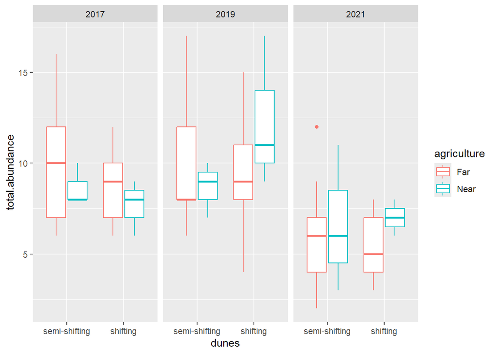

```r
ggplot(data = inland.sands, aes(x = dunes, y = total.abundance, color = agriculture)) + geom_boxplot() + facet_grid(. ~ year)
```

2021 seems lower than 2017 and 2019, but not other differences are obvious visually. Let’s fit the full Poisson model:

```r
# Inlands sands total abundance model selection----
inland.sands.total.abnd.model.full <- glmmTMB(total.abundance ~ year.count * agriculture + year.count * dunes + agriculture * dunes + sin.dist.21.June + cos.dist.21.June +
                                      site, family = 'poisson', data = inland.sands)
summary(inland.sands.total.abnd.model.full)
```

```
##  Family: poisson  ( log )
## Formula:
## total.abundance ~ year.count * agriculture + year.count * dunes +
##     agriculture * dunes + sin.dist.21.June + cos.dist.21.June +      site
## Data: inland.sands
##
##      AIC      BIC   logLik deviance df.resid
##    346.0    371.1   -162.0    324.0       61
##
##
## Conditional model:
##                               Estimate Std. Error z value Pr(>|z|)
## (Intercept)                    0.97236    0.86095   1.129 0.258725
## year.count                    -0.23702    0.05475  -4.329 1.50e-05 ***
## agricultureNear               -0.32692    0.18426  -1.774 0.076036 .
## dunesshifting                 -0.14710    0.13215  -1.113 0.265671
## sin.dist.21.June               1.45244    0.41755   3.478 0.000504 ***
## cos.dist.21.June               1.45984    0.82860   1.762 0.078102 .
## siteSecher                    -0.60532    0.13683  -4.424 9.69e-06 ***
## siteShunra East               -0.03756    0.11191  -0.336 0.737184
## year.count:agricultureNear     0.05121    0.06227   0.822 0.410930
## year.count:dunesshifting       0.01432    0.05341   0.268 0.788637
## agricultureNear:dunesshifting  0.32594    0.19046   1.711 0.087020 .
## ---
## Signif. codes:  0 '***' 0.001 '**' 0.01 '*' 0.05 '.' 0.1 ' ' 1
```

```r
cat('PHI = ');
```

```
## PHI =
```

```r
deviance(inland.sands.total.abnd.model.full)/df.residual(inland.sands.total.abnd.model.full)
```

```
## [1] 0.7221546
```

```r
drop1(inland.sands.total.abnd.model.full)
```

```
## Single term deletions
##
## Model:
## total.abundance ~ year.count * agriculture + year.count * dunes +
##     agriculture * dunes + sin.dist.21.June + cos.dist.21.June +
##     site
##                        Df    AIC
## <none>                    346.01
## sin.dist.21.June        1 356.24
## cos.dist.21.June        1 347.19
## site                    2 363.52
## year.count:agriculture  1 344.69
## year.count:dunes        1 344.08
## agriculture:dunes       1 346.95
```

PHI < 1, so we proceed with Poisson models. We can drop the interaction between trend and dune type:

```r
inland.sands.total.abnd.model1 <- glmmTMB(total.abundance ~ year.count * agriculture + dunes + agriculture * dunes + sin.dist.21.June + cos.dist.21.June +
                                      site, family = 'poisson', data = inland.sands)
summary(inland.sands.total.abnd.model1)
```

```
##  Family: poisson  ( log )
## Formula:
## total.abundance ~ year.count * agriculture + dunes + agriculture *
##     dunes + sin.dist.21.June + cos.dist.21.June + site
## Data: inland.sands
##
##      AIC      BIC   logLik deviance df.resid
##    344.1    366.9   -162.0    324.1       62
##
##
## Conditional model:
##                               Estimate Std. Error z value Pr(>|z|)
## (Intercept)                    0.95898    0.86039   1.115 0.265026
## year.count                    -0.23078    0.04950  -4.662 3.14e-06 ***
## agricultureNear               -0.32893    0.18476  -1.780 0.075023 .
## dunesshifting                 -0.12260    0.09542  -1.285 0.198826
## sin.dist.21.June               1.45657    0.41728   3.491 0.000482 ***
## cos.dist.21.June               1.46141    0.82936   1.762 0.078051 .
## siteSecher                    -0.60595    0.13685  -4.428 9.52e-06 ***
## siteShunra East               -0.03731    0.11191  -0.333 0.738853
## year.count:agricultureNear     0.05187    0.06224   0.833 0.404606
## agricultureNear:dunesshifting  0.32871    0.19014   1.729 0.083849 .
## ---
## Signif. codes:  0 '***' 0.001 '**' 0.01 '*' 0.05 '.' 0.1 ' ' 1
```

```r
drop1(inland.sands.total.abnd.model1)
```

```
## Single term deletions
##
## Model:
## total.abundance ~ year.count * agriculture + dunes + agriculture *
##     dunes + sin.dist.21.June + cos.dist.21.June + site
##                        Df    AIC
## <none>                    344.08
## sin.dist.21.June        1 354.40
## cos.dist.21.June        1 345.26
## site                    2 361.63
## year.count:agriculture  1 342.78
## agriculture:dunes       1 345.08
```

We can also drop the interaction between trend and distance to agriculture:

```r
inland.sands.total.abnd.model2 <- glmmTMB(total.abundance ~ year.count + agriculture * dunes + sin.dist.21.June + cos.dist.21.June + site, family = 'poisson', data = inland.sands)
summary(inland.sands.total.abnd.model2)
```

```
##  Family: poisson  ( log )
## Formula:
## total.abundance ~ year.count + agriculture * dunes + sin.dist.21.June +
##     cos.dist.21.June + site
## Data: inland.sands
##
##      AIC      BIC   logLik deviance df.resid
##    342.8    363.3   -162.4    324.8       63
##
##
## Conditional model:
##                               Estimate Std. Error z value Pr(>|z|)
## (Intercept)                    0.78305    0.83716   0.935 0.349598
## year.count                    -0.21710    0.04652  -4.667 3.06e-06 ***
## agricultureNear               -0.23823    0.14793  -1.610 0.107299
## dunesshifting                 -0.12260    0.09542  -1.285 0.198823
## sin.dist.21.June               1.50952    0.41187   3.665 0.000247 ***
## cos.dist.21.June               1.61059    0.81264   1.982 0.047489 *
## siteSecher                    -0.59818    0.13686  -4.371 1.24e-05 ***
## siteShunra East               -0.03803    0.11204  -0.339 0.734278
## agricultureNear:dunesshifting  0.33671    0.18994   1.773 0.076283 .
## ---
## Signif. codes:  0 '***' 0.001 '**' 0.01 '*' 0.05 '.' 0.1 ' ' 1
```

```r
drop1(inland.sands.total.abnd.model2)
```

```
## Single term deletions
##
## Model:
## total.abundance ~ year.count + agriculture * dunes + sin.dist.21.June +
##     cos.dist.21.June + site
##                   Df    AIC
## <none>               342.78
## year.count         1 364.27
## sin.dist.21.June   1 354.39
## cos.dist.21.June   1 344.80
## site               2 359.78
## agriculture:dunes  1 343.92
```

We can drop the last interaction standing, that between dune type and distance to agriculture:

```r
inland.sands.total.abnd.model3 <- glmmTMB(total.abundance ~ year.count + agriculture + dunes + sin.dist.21.June + cos.dist.21.June + site, family = 'poisson', data = inland.sands)
summary(inland.sands.total.abnd.model3)
```

```
##  Family: poisson  ( log )
## Formula:
## total.abundance ~ year.count + agriculture + dunes + sin.dist.21.June +
##     cos.dist.21.June + site
## Data: inland.sands
##
##      AIC      BIC   logLik deviance df.resid
##    343.9    362.1   -164.0    327.9       64
##
##
## Conditional model:
##                  Estimate Std. Error z value Pr(>|z|)
## (Intercept)       0.93491    0.83685   1.117 0.263920
## year.count       -0.21200    0.04645  -4.564 5.02e-06 ***
## agricultureNear  -0.07388    0.11205  -0.659 0.509648
## dunesshifting    -0.03766    0.08242  -0.457 0.647715
## sin.dist.21.June  1.40796    0.40982   3.436 0.000591 ***
## cos.dist.21.June  1.42386    0.81000   1.758 0.078772 .
## siteSecher       -0.59911    0.13712  -4.369 1.25e-05 ***
## siteShunra East  -0.03871    0.11214  -0.345 0.729936
## ---
## Signif. codes:  0 '***' 0.001 '**' 0.01 '*' 0.05 '.' 0.1 ' ' 1
```

```r
drop1(inland.sands.total.abnd.model3)
```

```
## Single term deletions
##
## Model:
## total.abundance ~ year.count + agriculture + dunes + sin.dist.21.June +
##     cos.dist.21.June + site
##                  Df    AIC
## <none>              343.92
## year.count        1 364.36
## agriculture       1 342.36
## dunes             1 342.13
## sin.dist.21.June  1 353.92
## cos.dist.21.June  1 345.09
## site              2 360.85
```

We can drop the dune type altogether:

```r
inland.sands.total.abnd.model4 <- glmmTMB(total.abundance ~ year.count + agriculture + sin.dist.21.June + cos.dist.21.June + site, family = 'poisson', data = inland.sands)
summary(inland.sands.total.abnd.model4)
```

```
##  Family: poisson  ( log )
## Formula:
## total.abundance ~ year.count + agriculture + sin.dist.21.June +
##     cos.dist.21.June + site
## Data: inland.sands
##
##      AIC      BIC   logLik deviance df.resid
##    342.1    358.1   -164.1    328.1       65
##
##
## Conditional model:
##                  Estimate Std. Error z value Pr(>|z|)
## (Intercept)       0.88717    0.82979   1.069 0.285004
## year.count       -0.21276    0.04642  -4.583 4.57e-06 ***
## agricultureNear  -0.07276    0.11203  -0.649 0.516026
## sin.dist.21.June  1.42327    0.40817   3.487 0.000489 ***
## cos.dist.21.June  1.45206    0.80704   1.799 0.071980 .
## siteSecher       -0.59896    0.13708  -4.370 1.24e-05 ***
## siteShunra East  -0.03861    0.11213  -0.344 0.730561
## ---
## Signif. codes:  0 '***' 0.001 '**' 0.01 '*' 0.05 '.' 0.1 ' ' 1
```

```r
drop1(inland.sands.total.abnd.model4)
```

```
## Single term deletions
##
## Model:
## total.abundance ~ year.count + agriculture + sin.dist.21.June +
##     cos.dist.21.June + site
##                  Df    AIC
## <none>              342.13
## year.count        1 362.78
## agriculture       1 340.55
## sin.dist.21.June  1 352.50
## cos.dist.21.June  1 343.45
## site              2 359.07
```

We can drop the distance to agriculture as well:

```r
inland.sands.total.abnd.model5 <- glmmTMB(total.abundance ~ year.count + sin.dist.21.June + cos.dist.21.June + site, family = 'poisson', data = inland.sands)
summary(inland.sands.total.abnd.model5)
```

```
##  Family: poisson  ( log )
## Formula:
## total.abundance ~ year.count + sin.dist.21.June + cos.dist.21.June +      site
## Data: inland.sands
##
##      AIC      BIC   logLik deviance df.resid
##    340.6    354.2   -164.3    328.6       66
##
##
## Conditional model:
##                   Estimate Std. Error z value Pr(>|z|)
## (Intercept)       0.853929   0.827987   1.031 0.302385
## year.count       -0.216587   0.045992  -4.709 2.49e-06 ***
## sin.dist.21.June  1.449808   0.405230   3.578 0.000347 ***
## cos.dist.21.June  1.449053   0.806896   1.796 0.072521 .
## siteSecher       -0.570651   0.130393  -4.376 1.21e-05 ***
## siteShunra East  -0.002674   0.097993  -0.027 0.978226
## ---
## Signif. codes:  0 '***' 0.001 '**' 0.01 '*' 0.05 '.' 0.1 ' ' 1
```

```r
drop1(inland.sands.total.abnd.model5)
```

```
## Single term deletions
##
## Model:
## total.abundance ~ year.count + sin.dist.21.June + cos.dist.21.June +
##     site
##                  Df    AIC
## <none>              340.55
## year.count        1 362.65
## sin.dist.21.June  1 351.62
## cos.dist.21.June  1 341.86
## site              2 357.35
```

We can drop cosine seasonality too as delta AIC < 2:

```r
inland.sands.total.abnd.model6 <- glmmTMB(total.abundance ~ year.count + sin.dist.21.June + site, family = 'poisson', data = inland.sands)
summary(inland.sands.total.abnd.model6)
```

```
##  Family: poisson  ( log )
## Formula:          total.abundance ~ year.count + sin.dist.21.June + site
## Data: inland.sands
##
##      AIC      BIC   logLik deviance df.resid
##    341.9    353.2   -165.9    331.9       67
##
##
## Conditional model:
##                  Estimate Std. Error z value Pr(>|z|)
## (Intercept)       2.33262    0.07406  31.497  < 2e-16 ***
## year.count       -0.21685    0.04672  -4.641 3.47e-06 ***
## sin.dist.21.June  0.91109    0.27370   3.329 0.000872 ***
## siteSecher       -0.62842    0.12721  -4.940 7.81e-07 ***
## siteShunra East   0.01253    0.09774   0.128 0.897960
## ---
## Signif. codes:  0 '***' 0.001 '**' 0.01 '*' 0.05 '.' 0.1 ' ' 1
```

```r
drop1(inland.sands.total.abnd.model6)
```

```
## Single term deletions
##
## Model:
## total.abundance ~ year.count + sin.dist.21.June + site
##                  Df    AIC
## <none>              341.86
## year.count        1 363.32
## sin.dist.21.June  1 351.17
## site              2 364.84
```

No more predictors to drop. Proceed to model diagnostics:

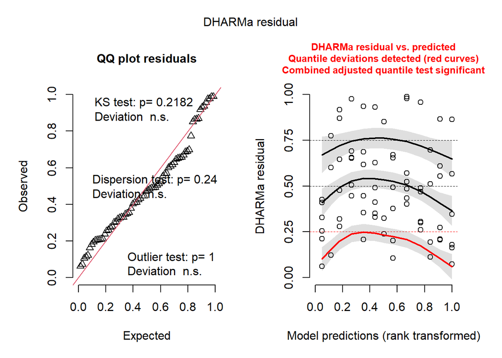

```r
# Inlands sands total abundance model diagnostics and back up----
inland.sands.abnd.sim.res <- simulateResiduals(inland.sands.total.abnd.model6) # simulate the residuals using DHARMa package for model diagnostics
plot(inland.sands.abnd.sim.res)
```

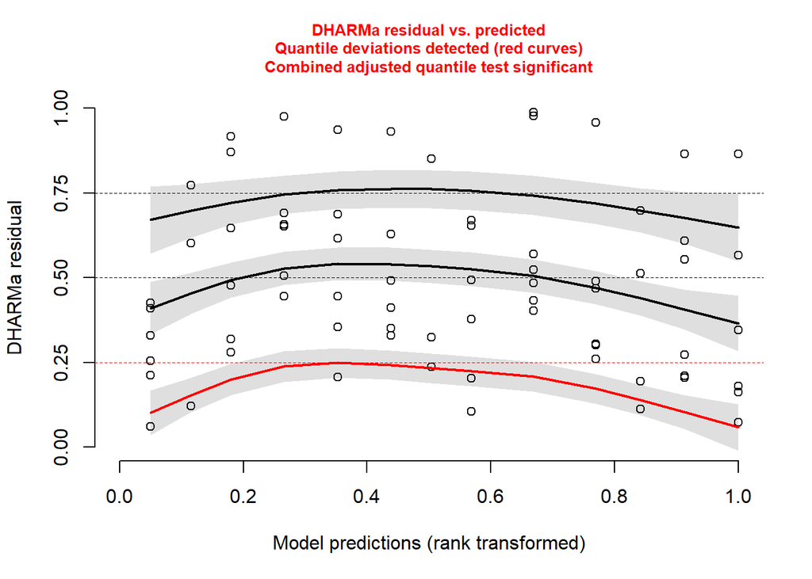

```
##
##  Test for location of quantiles via qgam
##
## data:  res
## p-value = 0.04173
## alternative hypothesis: both
```

```r
testQuantiles(inland.sands.abnd.sim.res)
```

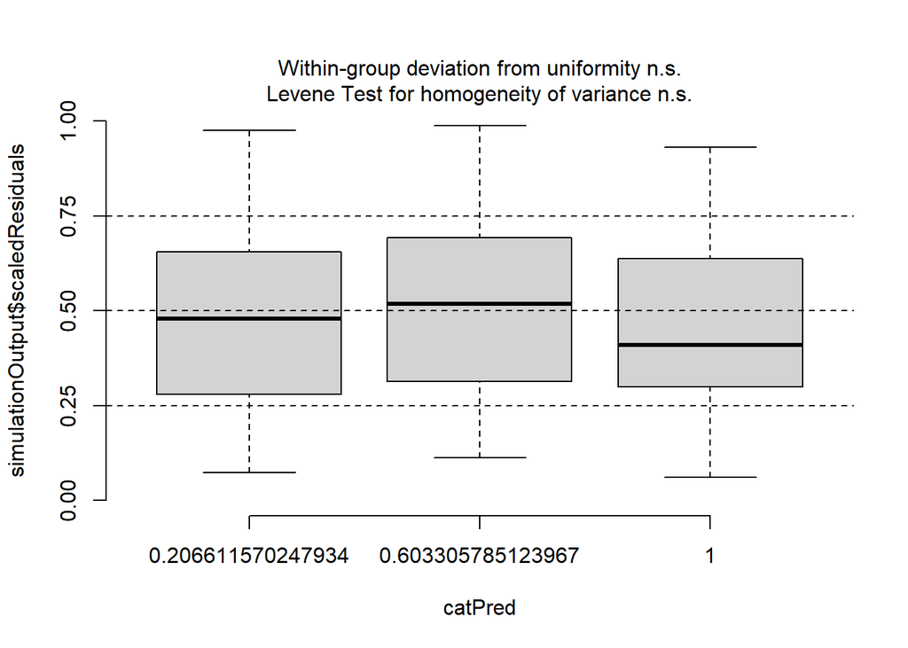

```r
plotResiduals(inland.sands.abnd.sim.res, form = inland.sands$year.count) #
```

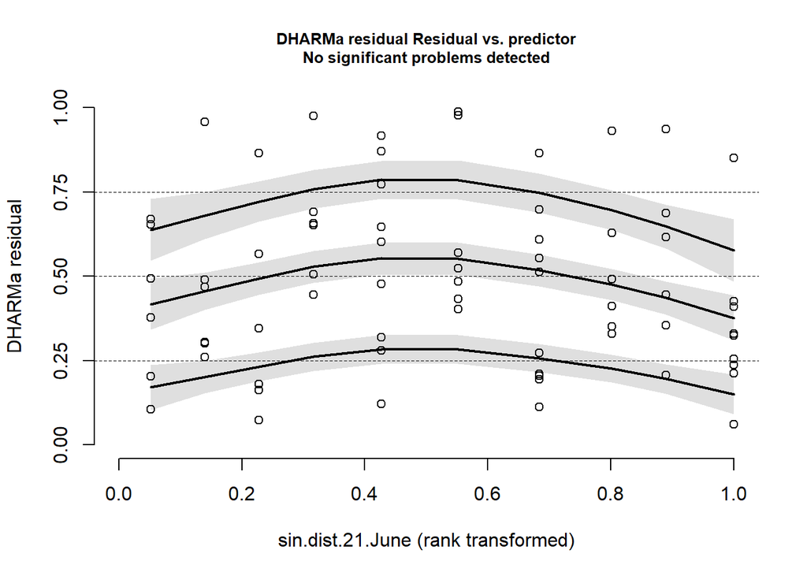

```r
plotResiduals(inland.sands.abnd.sim.res, form = inland.sands$sin.dist.21.June) #
```